# Survival models

## Objectives

1. Exploration
2. Determine model to use for binomial outcome variable (number of successes in n trials)
3. Evaluate model:
- fit
- qqplots
- outliers
- residuals vs temp
1. Test for interaction with land cover and temp
2. Produce graphs of relationship

## Exploration first

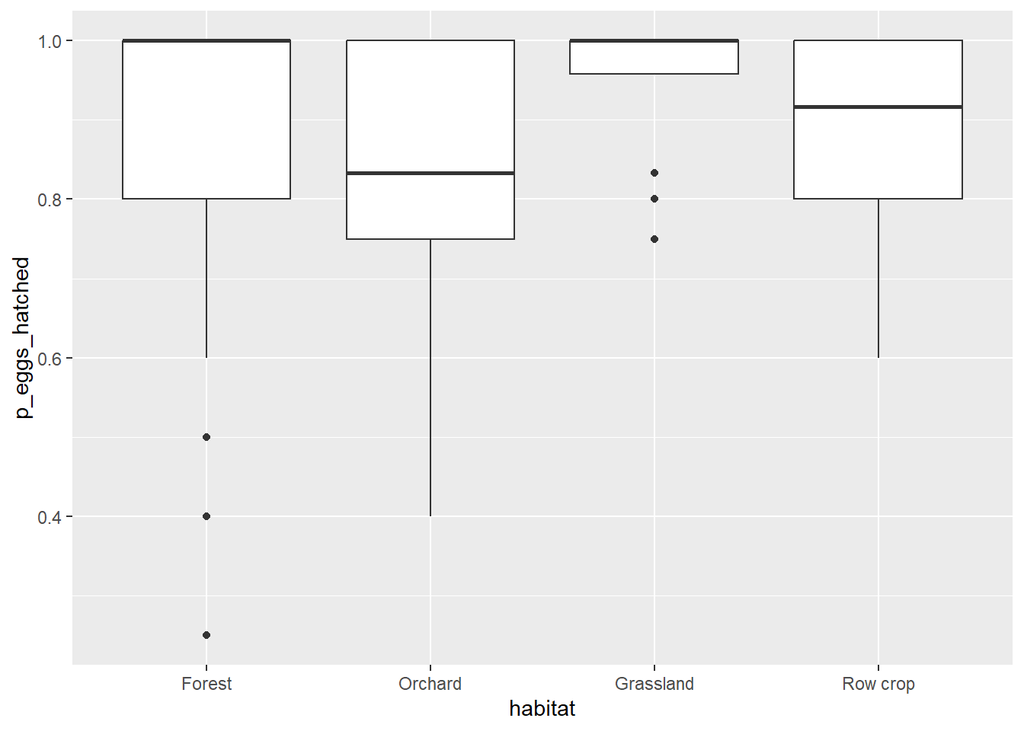

```r
ggplot(filter(s, Species == "WEBL"),aes(x = habitat, y = p_eggs_hatched)) + geom_boxplot()
```

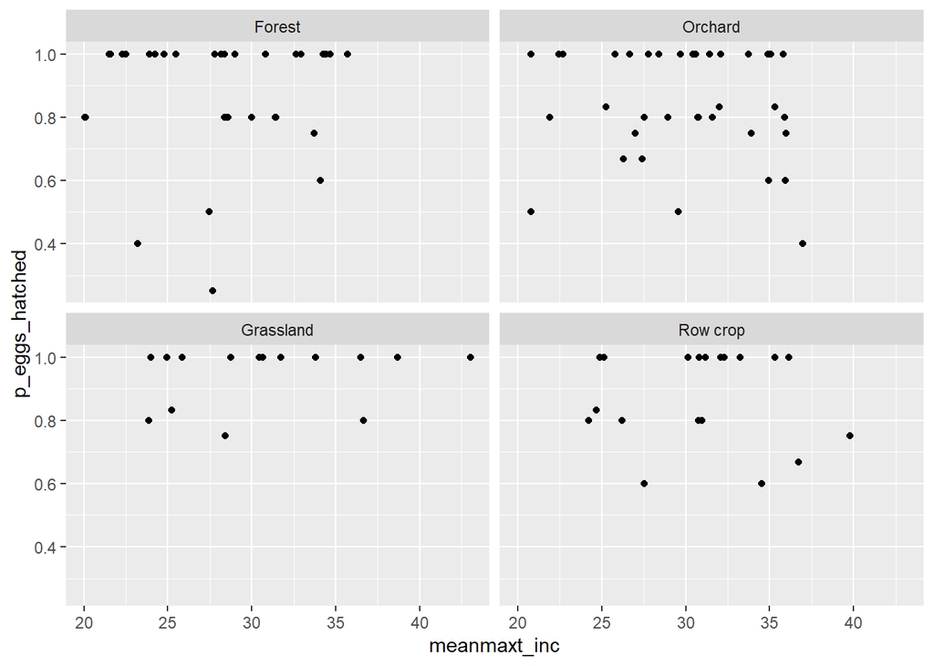

```r
ggplot(filter(s, Species == "WEBL"),aes(x = meanmaxt_inc, y = p_eggs_hatched)) + geom_point() + facet_wrap(~habitat)
```

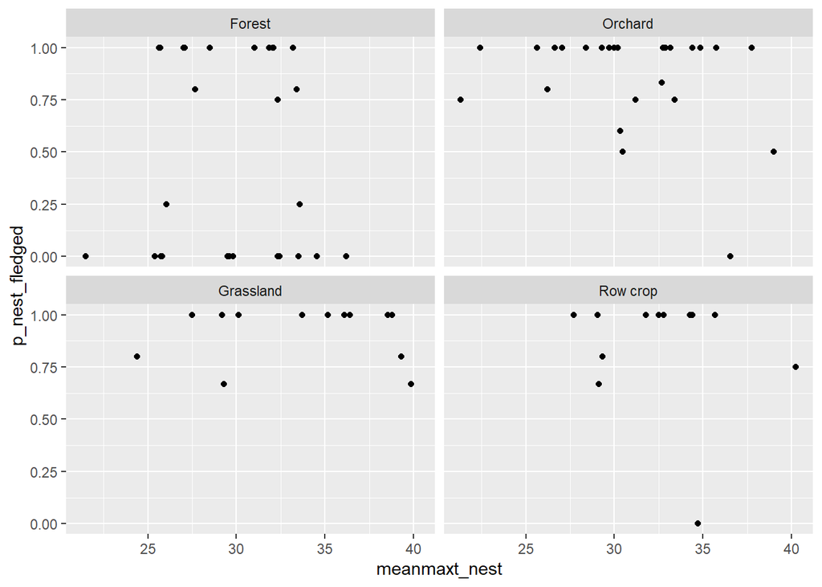

```r
# ggplot(filter(s, Species == "WEBL"),aes(x = meanmint_inc, y = p_eggs_hatched)) + geom_point() + facet_wrap(~habitat)

ggplot(filter(s, Species == "WEBL"),aes(x = meanmaxt_nest, y = p_nest_fledged)) + geom_point() + facet_wrap(~habitat)
```

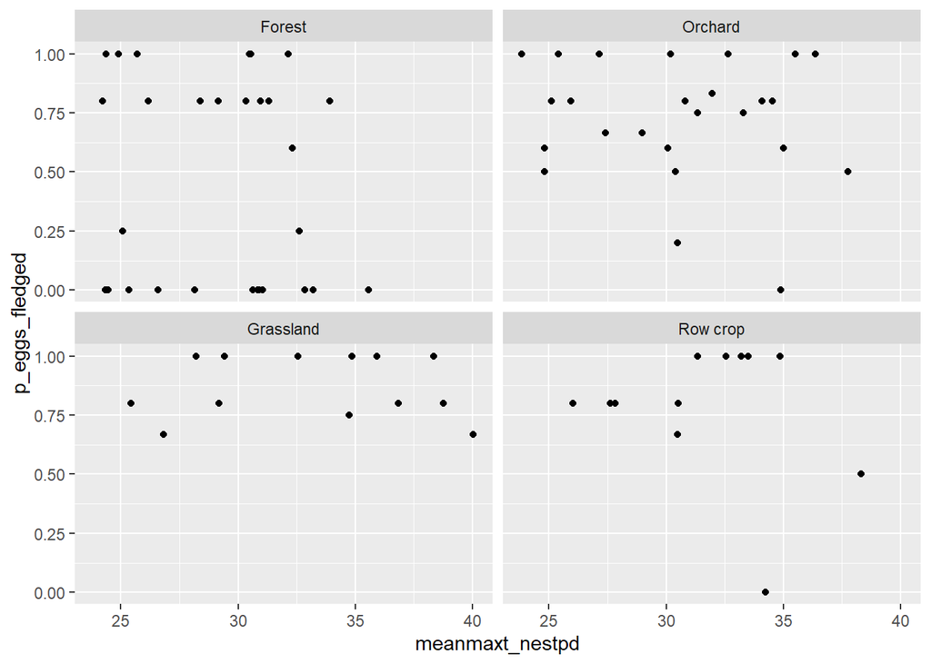

```r
ggplot(filter(s, Species == "WEBL"),aes(x = meanmaxt_nestpd, y = p_eggs_fledged)) + geom_point() + facet_wrap(~habitat)
```

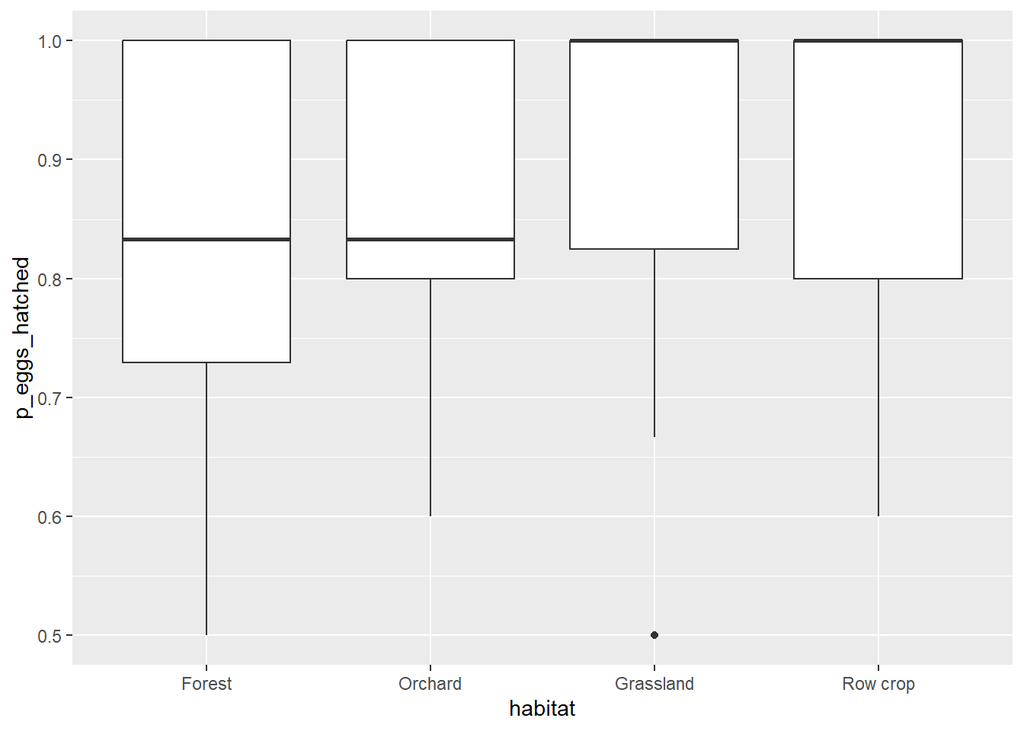

```r
ggplot(filter(s, Species == "TRES"),aes(x = habitat, y = p_eggs_hatched)) + geom_boxplot()
```

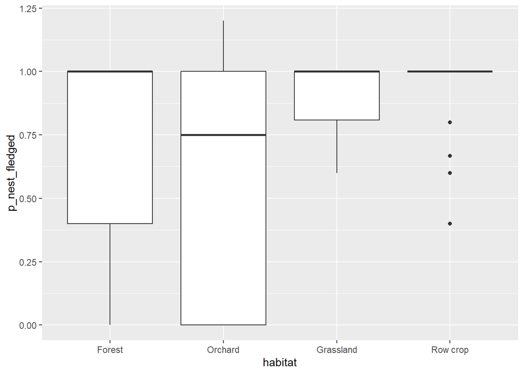

```r
ggplot(filter(s, Species == "TRES"),aes(x = habitat, y = p_nest_fledged)) + geom_boxplot()
```

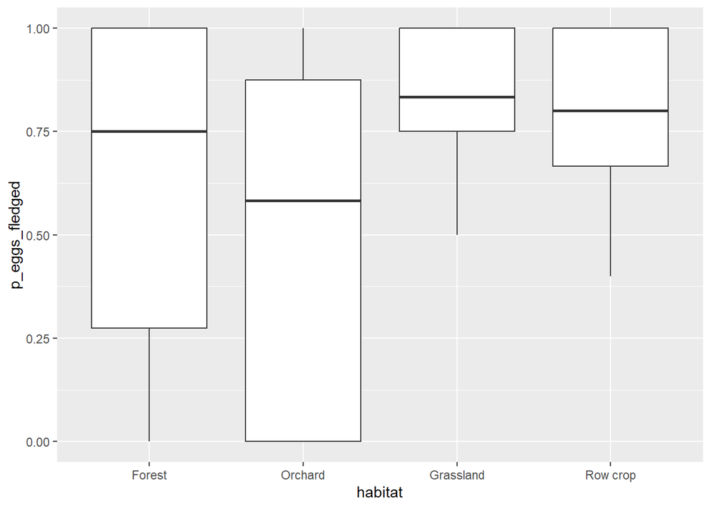

```r
ggplot(filter(s, Species == "TRES"),aes(x = habitat, y = p_eggs_fledged)) + geom_boxplot()
```

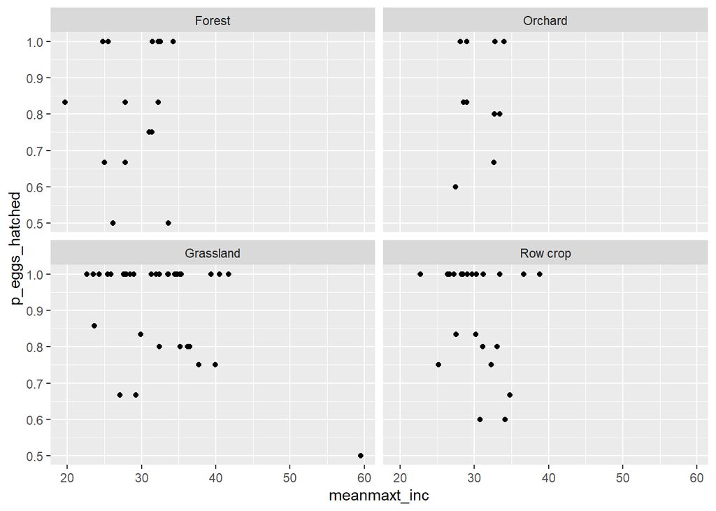

```r
ggplot(filter(s, Species == "TRES"),aes(x = meanmaxt_inc, y = p_eggs_hatched)) + geom_point() + facet_wrap(~habitat)
```

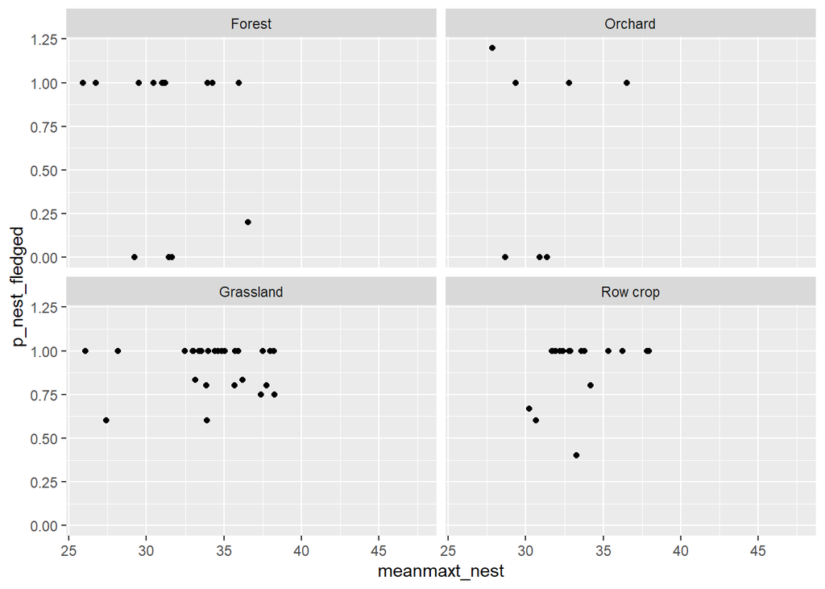

```r
# ggplot(filter(s, Species == "TRES"),aes(x = meanmint_inc, y = p_eggs_hatched)) + geom_point() + facet_wrap(~habitat)

ggplot(filter(s, Species == "TRES"),aes(x = meanmaxt_nest, y = p_nest_fledged)) + geom_point() + facet_wrap(~habitat)
```

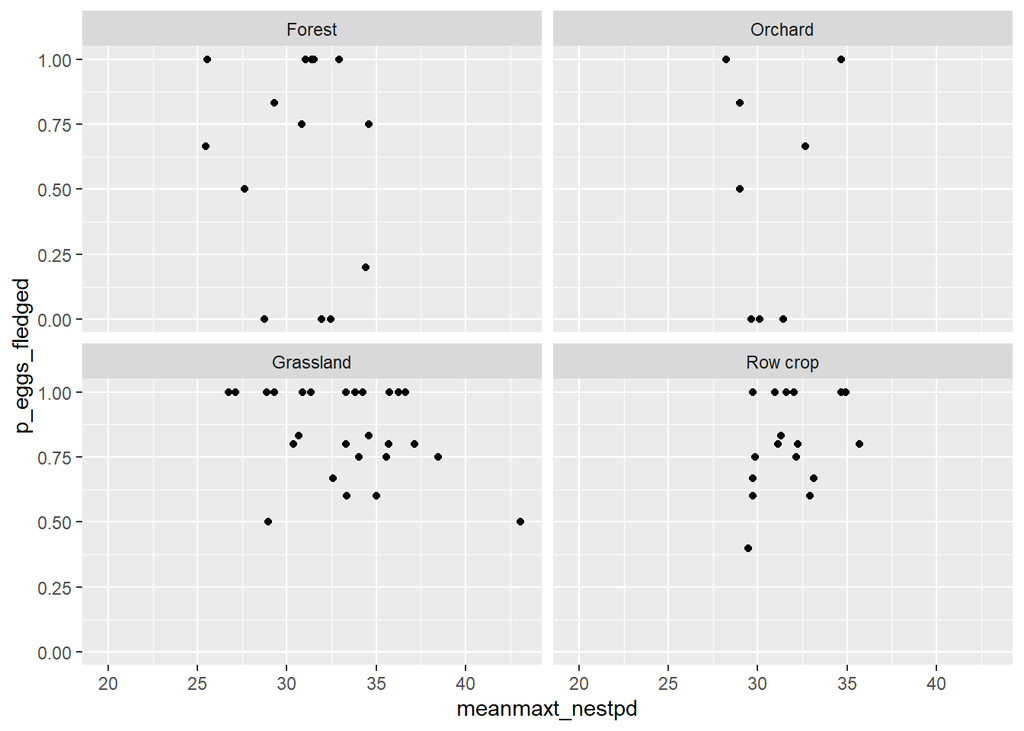

```r
ggplot(filter(s, Species == "TRES"),aes(x = meanmaxt_nestpd, y = p_eggs_fledged)) + geom_point() + facet_wrap(~habitat)
```

### WEBL

#### Incubation model

```r
s_inc_WEBL <- glm(cbind(eggs_hatched,clutch_size - eggs_hatched) ~ meanmaxt_inc_scaled * habitat + meanmint_inc_scaled * habitat + juliandate_inc_scaled + year_fct + site,
               family = binomial(link = "logit"),
               data = dplyr::filter(s,
                                    Species == "WEBL",
                                    !is.na(eggs_hatched),
                                    !is.na(clutch_size)) %>%
                 mutate(across(c(meanmaxt_inc,meanmint_inc,juliandate_inc),
                               ~ scale(.x)[,1],
                               .names = "{.col}_scaled")
                      )
               )
```

Using site as a random effect results in a singular fit, so I left it as a fixed effect.

```r
summary(s_inc_WEBL)
```

```
##
## Call:
## glm(formula = cbind(eggs_hatched, clutch_size - eggs_hatched) ~
##     meanmaxt_inc_scaled * habitat + meanmint_inc_scaled * habitat +
##         juliandate_inc_scaled + year_fct + site, family = binomial(link = "logit"),
##     data = dplyr::filter(s, Species == "WEBL", !is.na(eggs_hatched),
##         !is.na(clutch_size)) %>% mutate(across(c(meanmaxt_inc,
##         meanmint_inc, juliandate_inc), ~scale(.x)[, 1], .names = "{.col}_scaled")))
##
## Coefficients:
##                                      Estimate Std. Error z value Pr(>|z|)
## (Intercept)                           2.44524    0.54514   4.486 7.27e-06 ***
## meanmaxt_inc_scaled                   0.69688    0.61012   1.142   0.2534
## habitatOrchard                        0.14421    0.52833   0.273   0.7849
## habitatGrassland                      0.49510    0.77984   0.635   0.5255
## habitatRow crop                      -0.30769    0.49502  -0.622   0.5342
## meanmint_inc_scaled                  -0.77671    0.61025  -1.273   0.2031
## juliandate_inc_scaled                -0.02164    0.23939  -0.090   0.9280
## year_fct2022                         -0.04606    0.39332  -0.117   0.9068
## year_fct2023                         -0.30566    0.40722  -0.751   0.4529
## sitePG                               -0.37615    0.45634  -0.824   0.4098
## siteRR                                0.44168    0.61066   0.723   0.4695
## siteWI                               -1.25048    0.64673  -1.934   0.0532 .
## meanmaxt_inc_scaled:habitatOrchard   -1.03139    0.77207  -1.336   0.1816
## meanmaxt_inc_scaled:habitatGrassland -0.22910    0.98960  -0.232   0.8169
## meanmaxt_inc_scaled:habitatRow crop  -1.13943    0.93676  -1.216   0.2238
## habitatOrchard:meanmint_inc_scaled    0.93012    0.72831   1.277   0.2016
## habitatGrassland:meanmint_inc_scaled  0.54586    1.04448   0.523   0.6012
## habitatRow crop:meanmint_inc_scaled   1.25896    1.02123   1.233   0.2177
## ---
## Signif. codes:  0 '***' 0.001 '**' 0.01 '*' 0.05 '.' 0.1 ' ' 1
##
## (Dispersion parameter for binomial family taken to be 1)
##
##     Null deviance: 127.36  on 101  degrees of freedom
## Residual deviance: 109.06  on  84  degrees of freedom
##   (3 observations deleted due to missingness)
## AIC: 231.17
##
## Number of Fisher Scoring iterations: 5
```

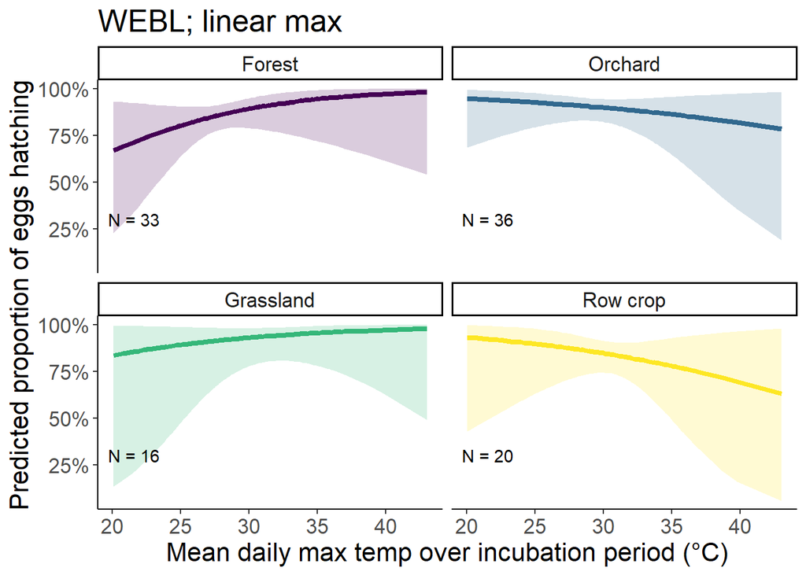

```r
data = dplyr::filter(s,
                                    Species == "WEBL",
                                    !is.na(eggs_hatched),
                                    !is.na(clutch_size)) %>%
                 mutate(across(c(meanmaxt_inc,meanmint_inc,juliandate_inc),
                               ~ scale(.x)[,1],
                               .names = "{.col}_scaled")
                      )

mean_temp <- mean(data %>% pull(meanmaxt_inc),na.rm = TRUE)
sd_temp <- sd(data %>% pull(meanmaxt_inc),na.rm = TRUE)


temp_trans <- trans_new("temp_trans",
                          transform = function(x){(x * sd_temp) + mean_temp},
                           inverse = function(x){x})

samp <- s_inc_WEBL$data %>% group_by(habitat) %>% summarize(count = n())
# samp %>% gt() %>% gtsave("../figures/ss_webl.html")


dat_text <- data.frame(
label = paste("N =",samp$count),
  group   = factor(samp$habitat)
)



(pl <- predict_response(s_inc_WEBL,terms = c("meanmaxt_inc_scaled [all]","habitat"),bias_correction = TRUE,margin = "empirical") %>%
   plot(line_size = 1.5,alpha = .2,show_data = TRUE,limit_range = TRUE) +
   theme_classic() +
   facet_wrap(~ group, ncol = 2) +
    xlab("Mean daily max temp over incubation period (\u00b0C)") +
    ylab("Predicted proportion of eggs hatching") +
   scale_fill_viridis(discrete = TRUE) +
    scale_color_viridis(discrete = TRUE) +
    theme(text = element_text(size = 16)) +
    labs(title = "WEBL; linear max") +
   scale_x_continuous(trans = temp_trans,
                       breaks = c((20-mean_temp)/sd_temp,
                                  (25-mean_temp)/sd_temp,
                                  (30-mean_temp)/sd_temp,
                                  (35-mean_temp)/sd_temp,
                                  (40-mean_temp)/sd_temp#,
                                  #(45-mean_temp)/sd_temp
                                  ),
                       # breaks = c(20,30,40,50),
                       # labels = c("20","30","40","50"),
                       # limits = c((15-mean(g$meanmaxtempI,na.rm = TRUE))/sd(g$meanmaxtempI,na.rm = TRUE),
                       #            (55-mean(g$meanmaxtempI,na.rm = TRUE))/sd(g$meanmaxtempI,na.rm = TRUE))
                       # limits = c(18,5)
                       ) +
   # ylim(0,100) +
   geom_text(data = dat_text, mapping = aes(x = -Inf, y = .3,label = label),hjust = -.2,inherit.aes = FALSE) +
    theme(legend.position = "none")
 )
```

#### Nestling model

```r
s_nest_WEBL <- glm(cbind(nest_fledged,brood_size - nest_fledged) ~ meanmaxt_nest_scaled * habitat + meanmint_nest_scaled * habitat + juliandate_inc_scaled + year_fct + site,
               family = binomial(link = "logit"),
               data = dplyr::filter(s,
                                    Species == "WEBL",
                                    !is.na(nest_fledged),
                                    !is.na(brood_size)) %>%
                 mutate(across(c(meanmaxt_nest,meanmint_nest,juliandate_inc),
                               ~ scale(.x)[,1],
                               .names = "{.col}_scaled")
                      )
               )
```

Using site as a random effect results in a singular fit, so I left it as a fixed effect.

```r
summary(s_inc_WEBL)
```

```
##
## Call:
## glm(formula = cbind(eggs_hatched, clutch_size - eggs_hatched) ~
##     meanmaxt_inc_scaled * habitat + meanmint_inc_scaled * habitat +
##         juliandate_inc_scaled + year_fct + site, family = binomial(link = "logit"),
##     data = dplyr::filter(s, Species == "WEBL", !is.na(eggs_hatched),
##         !is.na(clutch_size)) %>% mutate(across(c(meanmaxt_inc,
##         meanmint_inc, juliandate_inc), ~scale(.x)[, 1], .names = "{.col}_scaled")))
##
## Coefficients:
##                                      Estimate Std. Error z value Pr(>|z|)
## (Intercept)                           2.44524    0.54514   4.486 7.27e-06 ***
## meanmaxt_inc_scaled                   0.69688    0.61012   1.142   0.2534
## habitatOrchard                        0.14421    0.52833   0.273   0.7849
## habitatGrassland                      0.49510    0.77984   0.635   0.5255
## habitatRow crop                      -0.30769    0.49502  -0.622   0.5342
## meanmint_inc_scaled                  -0.77671    0.61025  -1.273   0.2031
## juliandate_inc_scaled                -0.02164    0.23939  -0.090   0.9280
## year_fct2022                         -0.04606    0.39332  -0.117   0.9068
## year_fct2023                         -0.30566    0.40722  -0.751   0.4529
## sitePG                               -0.37615    0.45634  -0.824   0.4098
## siteRR                                0.44168    0.61066   0.723   0.4695
## siteWI                               -1.25048    0.64673  -1.934   0.0532 .
## meanmaxt_inc_scaled:habitatOrchard   -1.03139    0.77207  -1.336   0.1816
## meanmaxt_inc_scaled:habitatGrassland -0.22910    0.98960  -0.232   0.8169
## meanmaxt_inc_scaled:habitatRow crop  -1.13943    0.93676  -1.216   0.2238
## habitatOrchard:meanmint_inc_scaled    0.93012    0.72831   1.277   0.2016
## habitatGrassland:meanmint_inc_scaled  0.54586    1.04448   0.523   0.6012
## habitatRow crop:meanmint_inc_scaled   1.25896    1.02123   1.233   0.2177
## ---
## Signif. codes:  0 '***' 0.001 '**' 0.01 '*' 0.05 '.' 0.1 ' ' 1
##
## (Dispersion parameter for binomial family taken to be 1)
##
##     Null deviance: 127.36  on 101  degrees of freedom
## Residual deviance: 109.06  on  84  degrees of freedom
##   (3 observations deleted due to missingness)
## AIC: 231.17
##
## Number of Fisher Scoring iterations: 5
```

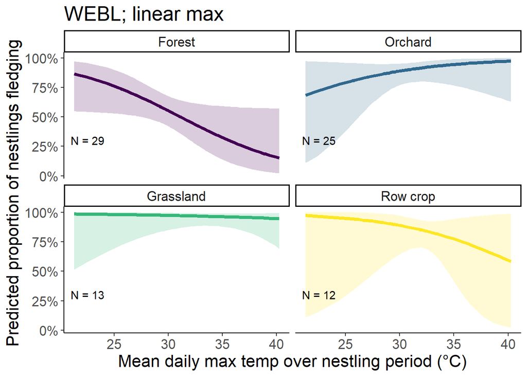

```r
data = dplyr::filter(s,
                                    Species == "WEBL",
                                    !is.na(nest_fledged),
                                    !is.na(brood_size)) %>%
                 mutate(across(c(meanmaxt_nest,meanmint_nest,juliandate_inc),
                               ~ scale(.x)[,1],
                               .names = "{.col}_scaled")
                      )

mean_temp <- mean(data %>% pull(meanmaxt_nest),na.rm = TRUE)
sd_temp <- sd(data %>% pull(meanmaxt_nest),na.rm = TRUE)


temp_trans <- trans_new("temp_trans",
                          transform = function(x){(x * sd_temp) + mean_temp},
                           inverse = function(x){x})

samp <- s_nest_WEBL$data %>% group_by(habitat) %>% summarize(count = n())
# samp %>% gt() %>% gtsave("../figures/ss_webl.html")


dat_text <- data.frame(
label = paste("N =",samp$count),
  group   = factor(samp$habitat)
)



(pl <- predict_response(s_nest_WEBL,terms = c("meanmaxt_nest_scaled [all]","habitat"),bias_correction = TRUE,margin = "empirical") %>%
   plot(line_size = 1.5,alpha = .2,show_data = TRUE,limit_range = TRUE) +
   theme_classic() +
   facet_wrap(~ group, ncol = 2) +
    xlab("Mean daily max temp over nestling period (\u00b0C)") +
    ylab("Predicted proportion of nestlings fledging") +
   scale_fill_viridis(discrete = TRUE) +
    scale_color_viridis(discrete = TRUE) +
    theme(text = element_text(size = 16)) +
    labs(title = "WEBL; linear max") +
   scale_x_continuous(trans = temp_trans,
                       breaks = c((20-mean_temp)/sd_temp,
                                  (25-mean_temp)/sd_temp,
                                  (30-mean_temp)/sd_temp,
                                  (35-mean_temp)/sd_temp,
                                  (40-mean_temp)/sd_temp#,
                                  #(45-mean_temp)/sd_temp
                                  ),
                       # breaks = c(20,30,40,50),
                       # labels = c("20","30","40","50"),
                       # limits = c((15-mean(g$meanmaxtempI,na.rm = TRUE))/sd(g$meanmaxtempI,na.rm = TRUE),
                       #            (55-mean(g$meanmaxtempI,na.rm = TRUE))/sd(g$meanmaxtempI,na.rm = TRUE))
                       # limits = c(18,5)
                       ) +
   # ylim(0,100) +
   geom_text(data = dat_text, mapping = aes(x = -Inf, y = .3,label = label),hjust = -.2,inherit.aes = FALSE) +
    theme(legend.position = "none")
 )
```

#### Nest period model

```r
s_nestpd_WEBL <- glm(cbind(nest_fledged,clutch_size - nest_fledged) ~ meanmaxt_nestpd_scaled * habitat + meanmint_nestpd_scaled * habitat + juliandate_inc_scaled + year_fct + site,
               family = binomial(link = "logit"),
               data = dplyr::filter(s,
                                    Species == "WEBL",
                                    !is.na(nest_fledged),
                                    !is.na(clutch_size)) %>%
                 mutate(across(c(meanmaxt_nestpd,meanmint_nestpd,juliandate_inc),
                               ~ scale(.x)[,1],
                               .names = "{.col}_scaled")
                      )
               )
```

Using site as a random effect results in a singular fit, so I left it as a fixed effect.

```r
summary(s_nestpd_WEBL)
```

```
##
## Call:
## glm(formula = cbind(nest_fledged, clutch_size - nest_fledged) ~
##     meanmaxt_nestpd_scaled * habitat + meanmint_nestpd_scaled *
##         habitat + juliandate_inc_scaled + year_fct + site, family = binomial(link = "logit"),
##     data = dplyr::filter(s, Species == "WEBL", !is.na(nest_fledged),
##         !is.na(clutch_size)) %>% mutate(across(c(meanmaxt_nestpd,
##         meanmint_nestpd, juliandate_inc), ~scale(.x)[, 1], .names = "{.col}_scaled")))
##
## Coefficients:
##                                         Estimate Std. Error z value Pr(>|z|)
## (Intercept)                              -1.0195     0.5367  -1.899 0.057516
## meanmaxt_nestpd_scaled                   -1.9587     0.6015  -3.256 0.001129
## habitatOrchard                            2.1031     0.4839   4.346 1.39e-05
## habitatGrassland                          2.9297     0.6966   4.206 2.60e-05
## habitatRow crop                           1.9089     0.4804   3.973 7.09e-05
## meanmint_nestpd_scaled                    2.1615     0.6188   3.493 0.000477
## juliandate_inc_scaled                    -0.3865     0.2916  -1.325 0.185034
## year_fct2022                              0.0476     0.4079   0.117 0.907098
## year_fct2023                             -0.4934     0.5199  -0.949 0.342659
## sitePG                                    0.6348     0.3856   1.647 0.099655
## siteRR                                    1.3774     0.5695   2.419 0.015569
## siteWI                                   -0.5086     0.5829  -0.873 0.382906
## meanmaxt_nestpd_scaled:habitatOrchard     2.3481     0.7545   3.112 0.001856
## meanmaxt_nestpd_scaled:habitatGrassland   1.7873     0.7563   2.363 0.018113
## meanmaxt_nestpd_scaled:habitatRow crop   -0.1893     1.2141  -0.156 0.876124
## habitatOrchard:meanmint_nestpd_scaled    -2.2802     0.6786  -3.360 0.000778
## habitatGrassland:meanmint_nestpd_scaled  -1.5825     0.9347  -1.693 0.090451
## habitatRow crop:meanmint_nestpd_scaled    0.1881     1.1569   0.163 0.870861
##
## (Intercept)                             .
## meanmaxt_nestpd_scaled                  **
## habitatOrchard                          ***
## habitatGrassland                        ***
## habitatRow crop                         ***
## meanmint_nestpd_scaled                  ***
## juliandate_inc_scaled
## year_fct2022
## year_fct2023
## sitePG                                  .
## siteRR                                  *
## siteWI
## meanmaxt_nestpd_scaled:habitatOrchard   **
## meanmaxt_nestpd_scaled:habitatGrassland *
## meanmaxt_nestpd_scaled:habitatRow crop
## habitatOrchard:meanmint_nestpd_scaled   ***
## habitatGrassland:meanmint_nestpd_scaled .
## habitatRow crop:meanmint_nestpd_scaled
## ---
## Signif. codes:  0 '***' 0.001 '**' 0.01 '*' 0.05 '.' 0.1 ' ' 1
##
## (Dispersion parameter for binomial family taken to be 1)
##
##     Null deviance: 247.68  on 77  degrees of freedom
## Residual deviance: 176.17  on 60  degrees of freedom
##   (1 observation deleted due to missingness)
## AIC: 289.48
##
## Number of Fisher Scoring iterations: 5
```

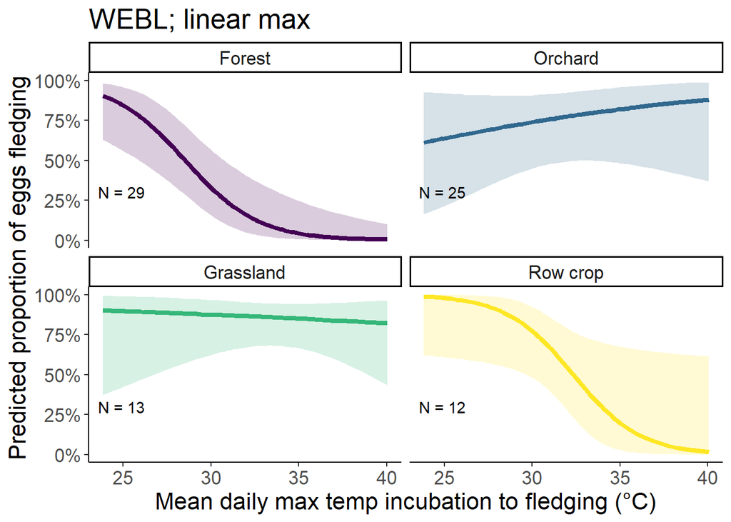

```r
mean_temp <- mean(s_nestpd_WEBL$data %>% pull(meanmaxt_nestpd),na.rm = TRUE)
sd_temp <- sd(s_nestpd_WEBL$data %>% pull(meanmaxt_nestpd),na.rm = TRUE)


temp_trans <- trans_new("temp_trans",
                          transform = function(x){(x * sd_temp) + mean_temp},
                           inverse = function(x){x})

samp <- s_nestpd_WEBL$data %>% group_by(habitat) %>% summarize(count = n())
# samp %>% gt() %>% gtsave("../figures/ss_webl.html")


dat_text <- data.frame(
label = paste("N =",samp$count),
  group   = factor(samp$habitat)
)



(pl <- predict_response(s_nestpd_WEBL,terms = c("meanmaxt_nestpd_scaled [all]","habitat"),bias_correction = TRUE) %>%
   plot(line_size = 1.5,alpha = .2,show_data = TRUE,limit_range = TRUE) +
   theme_classic() +
   facet_wrap(~ group, ncol = 2) +
    xlab("Mean daily max temp incubation to fledging (\u00b0C)") +
    ylab("Predicted proportion of eggs fledging") +
   scale_fill_viridis(discrete = TRUE) +
    scale_color_viridis(discrete = TRUE) +
    theme(text = element_text(size = 16)) +
    labs(title = "WEBL; linear max") +
   scale_x_continuous(trans = temp_trans,
                       breaks = c((20-mean_temp)/sd_temp,
                                  (25-mean_temp)/sd_temp,
                                  (30-mean_temp)/sd_temp,
                                  (35-mean_temp)/sd_temp,
                                  (40-mean_temp)/sd_temp#,
                                  #(45-mean_temp)/sd_temp
                                  ),
                       # breaks = c(20,30,40,50),
                       # labels = c("20","30","40","50"),
                       # limits = c((15-mean(g$meanmaxtempI,na.rm = TRUE))/sd(g$meanmaxtempI,na.rm = TRUE),
                       #            (55-mean(g$meanmaxtempI,na.rm = TRUE))/sd(g$meanmaxtempI,na.rm = TRUE))
                       # limits = c(18,5)
                       ) +
   # ylim(0,100) +
   geom_text(data = dat_text, mapping = aes(x = -Inf, y = .3,label = label),hjust = -.2,inherit.aes = FALSE) +
    theme(legend.position = "none")
 )
```

### TRES

#### Incubation model

```r
s_inc_TRES <- glm(cbind(eggs_hatched,clutch_size - eggs_hatched) ~ meanmaxt_inc_scaled * habitat + meanmint_inc_scaled * habitat + juliandate_inc_scaled + year_fct + site,
               family = binomial(link = "logit"),
               data = dplyr::filter(s,
                                    Species == "TRES",
                                    !is.na(eggs_hatched),
                                    !is.na(clutch_size),
                                    meanmaxt_inc < 50) %>%
                 mutate(across(c(meanmaxt_inc,meanmint_inc,juliandate_inc),
                               ~ scale(.x)[,1],
                               .names = "{.col}_scaled")
                      )
               )
```

Using site as a random effect results in a singular fit, so I left it as a fixed effect.

```r
summary(s_inc_TRES)
```

```
##
## Call:
## glm(formula = cbind(eggs_hatched, clutch_size - eggs_hatched) ~
##     meanmaxt_inc_scaled * habitat + meanmint_inc_scaled * habitat +
##         juliandate_inc_scaled + year_fct + site, family = binomial(link = "logit"),
##     data = dplyr::filter(s, Species == "TRES", !is.na(eggs_hatched),
##         !is.na(clutch_size), meanmaxt_inc < 50) %>% mutate(across(c(meanmaxt_inc,
##         meanmint_inc, juliandate_inc), ~scale(.x)[, 1], .names = "{.col}_scaled")))
##
## Coefficients:
##                                       Estimate Std. Error z value Pr(>|z|)
## (Intercept)                           1.803979   0.479965   3.759 0.000171 ***
## meanmaxt_inc_scaled                  -0.002279   0.453211  -0.005 0.995988
## habitatOrchard                       -0.308178   0.984984  -0.313 0.754375
## habitatGrassland                      1.448372   0.618145   2.343 0.019125 *
## habitatRow crop                       1.109832   0.562270   1.974 0.048400 *
## meanmint_inc_scaled                   0.767724   0.784725   0.978 0.327908
## juliandate_inc_scaled                -0.053833   0.281853  -0.191 0.848528
## year_fct2022                         -0.050870   0.424335  -0.120 0.904577
## year_fct2023                         -0.205470   0.473930  -0.434 0.664618
## sitePG                               -0.473096   0.527791  -0.896 0.370055
## siteRR                               -0.963085   0.475249  -2.026 0.042715 *
## siteWI                                0.791059   1.734211   0.456 0.648283
## meanmaxt_inc_scaled:habitatOrchard    0.398984   1.128661   0.354 0.723712
## meanmaxt_inc_scaled:habitatGrassland -0.275505   0.714517  -0.386 0.699807
## meanmaxt_inc_scaled:habitatRow crop   0.256355   0.810172   0.316 0.751684
## habitatOrchard:meanmint_inc_scaled   -1.025235   1.165251  -0.880 0.378946
## habitatGrassland:meanmint_inc_scaled -0.533850   0.907818  -0.588 0.556493
## habitatRow crop:meanmint_inc_scaled  -1.349928   0.989398  -1.364 0.172444
## ---
## Signif. codes:  0 '***' 0.001 '**' 0.01 '*' 0.05 '.' 0.1 ' ' 1
##
## (Dispersion parameter for binomial family taken to be 1)
##
##     Null deviance: 96.695  on 82  degrees of freedom
## Residual deviance: 79.101  on 65  degrees of freedom
## AIC: 180.54
##
## Number of Fisher Scoring iterations: 5
```

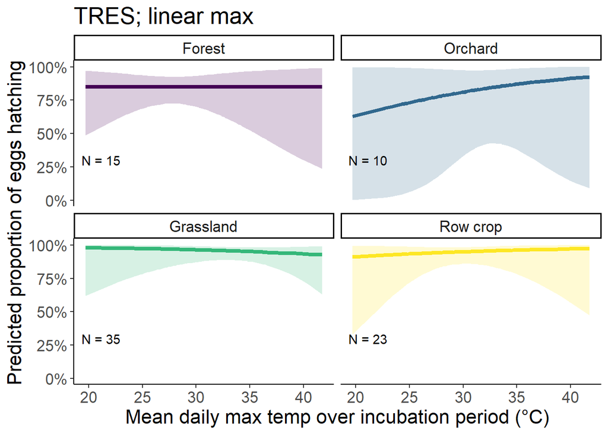

```r
data = s_inc_TRES$data

mean_temp <- mean(data %>% pull(meanmaxt_inc),na.rm = TRUE)
sd_temp <- sd(data %>% pull(meanmaxt_inc),na.rm = TRUE)


temp_trans <- trans_new("temp_trans",
                          transform = function(x){(x * sd_temp) + mean_temp},
                           inverse = function(x){x})

samp <- s_inc_TRES$data %>% group_by(habitat) %>% summarize(count = n())
# samp %>% gt() %>% gtsave("../figures/ss_TRES.html")


dat_text <- data.frame(
label = paste("N =",samp$count),
  group   = factor(samp$habitat)
)



(pl <- predict_response(s_inc_TRES,terms = c("meanmaxt_inc_scaled [all]","habitat"),bias_correction = TRUE) %>%
   plot(line_size = 1.5,alpha = .2,show_data = TRUE,limit_range = TRUE) +
   theme_classic() +
   facet_wrap(~ group, ncol = 2) +
    xlab("Mean daily max temp over incubation period (\u00b0C)") +
    ylab("Predicted proportion of eggs hatching") +
   scale_fill_viridis(discrete = TRUE) +
    scale_color_viridis(discrete = TRUE) +
    theme(text = element_text(size = 16)) +
    labs(title = "TRES; linear max") +
   scale_x_continuous(trans = temp_trans,
                       breaks = c((20-mean_temp)/sd_temp,
                                  (25-mean_temp)/sd_temp,
                                  (30-mean_temp)/sd_temp,
                                  (35-mean_temp)/sd_temp,
                                  (40-mean_temp)/sd_temp#,
                                  #(45-mean_temp)/sd_temp
                                  ),
                       # breaks = c(20,30,40,50),
                       # labels = c("20","30","40","50"),
                       # limits = c((15-mean(g$meanmaxtempI,na.rm = TRUE))/sd(g$meanmaxtempI,na.rm = TRUE),
                       #            (55-mean(g$meanmaxtempI,na.rm = TRUE))/sd(g$meanmaxtempI,na.rm = TRUE))
                       # limits = c(18,5)
                       ) +
   # ylim(0,100) +
   geom_text(data = dat_text, mapping = aes(x = -Inf, y = .3,label = label),hjust = -.2,inherit.aes = FALSE) +
    theme(legend.position = "none")
 )
```

#### Nestling model

```r
s_nest_TRES <- glm(cbind(nest_fledged,brood_size - nest_fledged) ~ meanmaxt_nest_scaled * habitat + meanmint_nest_scaled * habitat + juliandate_inc_scaled + year_fct + site,
               family = binomial(link = "logit"),
               data = dplyr::filter(s,
                                    Species == "TRES",
                                    !is.na(nest_fledged),
                                    !is.na(brood_size),
                                    meanmaxt_nest < 50) %>%
                 mutate(across(c(meanmaxt_nest,meanmint_nest,juliandate_inc),
                               ~ scale(.x)[,1],
                               .names = "{.col}_scaled")
                      )
               )
```

Using site as a random effect results in a singular fit, so I left it as a fixed effect.

```r
summary(s_inc_TRES)
```

```
##
## Call:
## glm(formula = cbind(eggs_hatched, clutch_size - eggs_hatched) ~
##     meanmaxt_inc_scaled * habitat + meanmint_inc_scaled * habitat +
##         juliandate_inc_scaled + year_fct + site, family = binomial(link = "logit"),
##     data = dplyr::filter(s, Species == "TRES", !is.na(eggs_hatched),
##         !is.na(clutch_size), meanmaxt_inc < 50) %>% mutate(across(c(meanmaxt_inc,
##         meanmint_inc, juliandate_inc), ~scale(.x)[, 1], .names = "{.col}_scaled")))
##
## Coefficients:
##                                       Estimate Std. Error z value Pr(>|z|)
## (Intercept)                           1.803979   0.479965   3.759 0.000171 ***
## meanmaxt_inc_scaled                  -0.002279   0.453211  -0.005 0.995988
## habitatOrchard                       -0.308178   0.984984  -0.313 0.754375
## habitatGrassland                      1.448372   0.618145   2.343 0.019125 *
## habitatRow crop                       1.109832   0.562270   1.974 0.048400 *
## meanmint_inc_scaled                   0.767724   0.784725   0.978 0.327908
## juliandate_inc_scaled                -0.053833   0.281853  -0.191 0.848528
## year_fct2022                         -0.050870   0.424335  -0.120 0.904577
## year_fct2023                         -0.205470   0.473930  -0.434 0.664618
## sitePG                               -0.473096   0.527791  -0.896 0.370055
## siteRR                               -0.963085   0.475249  -2.026 0.042715 *
## siteWI                                0.791059   1.734211   0.456 0.648283
## meanmaxt_inc_scaled:habitatOrchard    0.398984   1.128661   0.354 0.723712
## meanmaxt_inc_scaled:habitatGrassland -0.275505   0.714517  -0.386 0.699807
## meanmaxt_inc_scaled:habitatRow crop   0.256355   0.810172   0.316 0.751684
## habitatOrchard:meanmint_inc_scaled   -1.025235   1.165251  -0.880 0.378946
## habitatGrassland:meanmint_inc_scaled -0.533850   0.907818  -0.588 0.556493
## habitatRow crop:meanmint_inc_scaled  -1.349928   0.989398  -1.364 0.172444
## ---
## Signif. codes:  0 '***' 0.001 '**' 0.01 '*' 0.05 '.' 0.1 ' ' 1
##
## (Dispersion parameter for binomial family taken to be 1)
##
##     Null deviance: 96.695  on 82  degrees of freedom
## Residual deviance: 79.101  on 65  degrees of freedom
## AIC: 180.54
##
## Number of Fisher Scoring iterations: 5
```

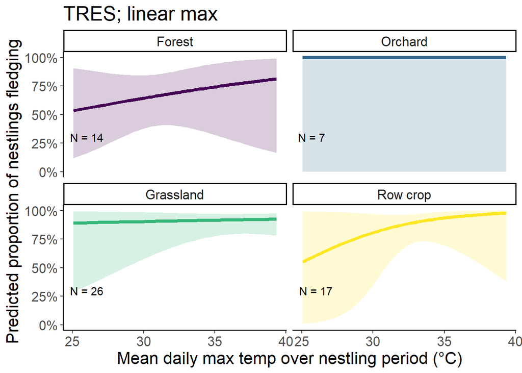

```r
data = s_inc_TRES$data

mean_temp <- mean(data %>% pull(meanmaxt_nest),na.rm = TRUE)
sd_temp <- sd(data %>% pull(meanmaxt_nest),na.rm = TRUE)


temp_trans <- trans_new("temp_trans",
                          transform = function(x){(x * sd_temp) + mean_temp},
                           inverse = function(x){x})

samp <- s_nest_TRES$data %>% group_by(habitat) %>% summarize(count = n())
# samp %>% gt() %>% gtsave("../figures/ss_TRES.html")


dat_text <- data.frame(
label = paste("N =",samp$count),
  group   = factor(samp$habitat)
)



(pl <- predict_response(s_nest_TRES,terms = c("meanmaxt_nest_scaled [all]","habitat"),bias_correction = TRUE) %>%
   plot(line_size = 1.5,alpha = .2,show_data = TRUE,limit_range = TRUE) +
   theme_classic() +
   facet_wrap(~ group, ncol = 2) +
    xlab("Mean daily max temp over nestling period (\u00b0C)") +
    ylab("Predicted proportion of nestlings fledging") +
   scale_fill_viridis(discrete = TRUE) +
    scale_color_viridis(discrete = TRUE) +
    theme(text = element_text(size = 16)) +
    labs(title = "TRES; linear max") +
   scale_x_continuous(trans = temp_trans,
                       breaks = c((20-mean_temp)/sd_temp,
                                  (25-mean_temp)/sd_temp,
                                  (30-mean_temp)/sd_temp,
                                  (35-mean_temp)/sd_temp,
                                  (40-mean_temp)/sd_temp#,
                                  #(45-mean_temp)/sd_temp
                                  ),
                       # breaks = c(20,30,40,50),
                       # labels = c("20","30","40","50"),
                       # limits = c((15-mean(g$meanmaxtempI,na.rm = TRUE))/sd(g$meanmaxtempI,na.rm = TRUE),
                       #            (55-mean(g$meanmaxtempI,na.rm = TRUE))/sd(g$meanmaxtempI,na.rm = TRUE))
                       # limits = c(18,5)
                       ) +
   # ylim(0,100) +
   geom_text(data = dat_text, mapping = aes(x = -Inf, y = .3,label = label),hjust = -.2,inherit.aes = FALSE) +
    theme(legend.position = "none")
 )
```

#### Nest period model

```r
s_nestpd_TRES <- glm(cbind(nest_fledged,clutch_size - nest_fledged) ~ meanmaxt_nestpd_scaled * habitat + meanmint_nestpd_scaled * habitat + juliandate_inc_scaled + year_fct + site,
               family = binomial(link = "logit"),
               data = dplyr::filter(s,
                                    Species == "TRES",
                                    !is.na(nest_fledged),
                                    !is.na(clutch_size),
                                    meanmaxt_nestpd < 50) %>%
                 mutate(across(c(meanmaxt_nestpd,meanmint_nestpd,juliandate_inc),
                               ~ scale(.x)[,1],
                               .names = "{.col}_scaled")
                      )
               )
```

Using site as a random effect results in a singular fit, so I left it as a fixed effect.

```r
summary(s_nestpd_TRES)
```

```
##
## Call:
## glm(formula = cbind(nest_fledged, clutch_size - nest_fledged) ~
##     meanmaxt_nestpd_scaled * habitat + meanmint_nestpd_scaled *
##         habitat + juliandate_inc_scaled + year_fct + site, family = binomial(link = "logit"),
##     data = dplyr::filter(s, Species == "TRES", !is.na(nest_fledged),
##         !is.na(clutch_size), meanmaxt_nestpd < 50) %>% mutate(across(c(meanmaxt_nestpd,
##         meanmint_nestpd, juliandate_inc), ~scale(.x)[, 1], .names = "{.col}_scaled")))
##
## Coefficients:
##                                         Estimate Std. Error z value Pr(>|z|)
## (Intercept)                              0.27833    0.49810   0.559  0.57630
## meanmaxt_nestpd_scaled                   0.38929    0.54325   0.717  0.47363
## habitatOrchard                          -0.07759    0.91578  -0.085  0.93248
## habitatGrassland                         1.57641    0.56038   2.813  0.00491 **
## habitatRow crop                          1.07253    0.58198   1.843  0.06534 .
## meanmint_nestpd_scaled                  -0.07534    0.68343  -0.110  0.91222
## juliandate_inc_scaled                   -0.70957    0.30022  -2.364  0.01810 *
## year_fct2022                             0.77399    0.36548   2.118  0.03420 *
## year_fct2023                             1.07246    0.51571   2.080  0.03757 *
## sitePG                                  -0.24685    0.45310  -0.545  0.58590
## siteRR                                  -0.77587    0.44060  -1.761  0.07824 .
## siteWI                                  -0.49967    1.13407  -0.441  0.65950
## meanmaxt_nestpd_scaled:habitatOrchard    0.38094    0.80870   0.471  0.63760
## meanmaxt_nestpd_scaled:habitatGrassland -0.62765    0.61238  -1.025  0.30539
## meanmaxt_nestpd_scaled:habitatRow crop   0.64132    0.96313   0.666  0.50549
## habitatOrchard:meanmint_nestpd_scaled   -0.35236    0.80759  -0.436  0.66261
## habitatGrassland:meanmint_nestpd_scaled  0.73244    0.73687   0.994  0.32023
## habitatRow crop:meanmint_nestpd_scaled   0.37128    1.00066   0.371  0.71061
## ---
## Signif. codes:  0 '***' 0.001 '**' 0.01 '*' 0.05 '.' 0.1 ' ' 1
##
## (Dispersion parameter for binomial family taken to be 1)
##
##     Null deviance: 181.27  on 64  degrees of freedom
## Residual deviance: 130.05  on 47  degrees of freedom
## AIC: 231.85
##
## Number of Fisher Scoring iterations: 5
```

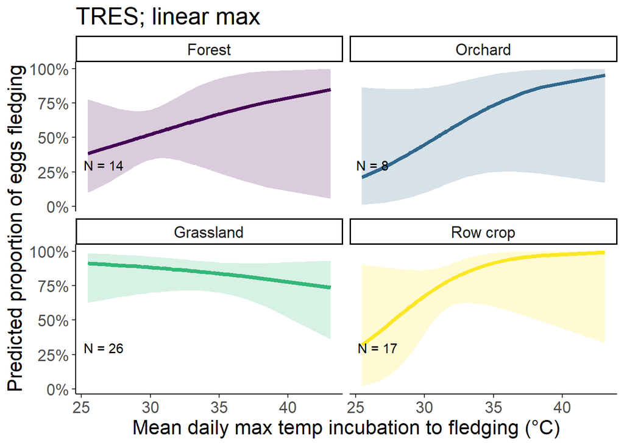

```r
mean_temp <- mean(s_nestpd_TRES$data %>% pull(meanmaxt_nestpd),na.rm = TRUE)
sd_temp <- sd(s_nestpd_TRES$data %>% pull(meanmaxt_nestpd),na.rm = TRUE)


temp_trans <- trans_new("temp_trans",
                          transform = function(x){(x * sd_temp) + mean_temp},
                           inverse = function(x){x})

samp <- s_nestpd_TRES$data %>% group_by(habitat) %>% summarize(count = n())
# samp %>% gt() %>% gtsave("../figures/ss_TRES.html")


dat_text <- data.frame(
label = paste("N =",samp$count),
  group   = factor(samp$habitat)
)



(pl <- predict_response(s_nestpd_TRES,terms = c("meanmaxt_nestpd_scaled [all]","habitat")) %>%
   plot(line_size = 1.5,alpha = .2,show_data = TRUE,limit_range = TRUE) +
   theme_classic() +
   facet_wrap(~ group, ncol = 2) +
    xlab("Mean daily max temp incubation to fledging (\u00b0C)") +
    ylab("Predicted proportion of eggs fledging") +
   scale_fill_viridis(discrete = TRUE) +
    scale_color_viridis(discrete = TRUE) +
    theme(text = element_text(size = 16)) +
    labs(title = "TRES; linear max") +
   scale_x_continuous(trans = temp_trans,
                       breaks = c((20-mean_temp)/sd_temp,
                                  (25-mean_temp)/sd_temp,
                                  (30-mean_temp)/sd_temp,
                                  (35-mean_temp)/sd_temp,
                                  (40-mean_temp)/sd_temp#,
                                  #(45-mean_temp)/sd_temp
                                  ),
                       # breaks = c(20,30,40,50),
                       # labels = c("20","30","40","50"),
                       # limits = c((15-mean(g$meanmaxtempI,na.rm = TRUE))/sd(g$meanmaxtempI,na.rm = TRUE),
                       #            (55-mean(g$meanmaxtempI,na.rm = TRUE))/sd(g$meanmaxtempI,na.rm = TRUE))
                       # limits = c(18,5)
                       ) +
   # ylim(0,100) +
   geom_text(data = dat_text, mapping = aes(x = -Inf, y = .3,label = label),hjust = -.2,inherit.aes = FALSE) +
    theme(legend.position = "none")
 )
```

## Test for interaction with land cover and temp

### WEBL

#### Incubation model

```r
s_inc_WEBL <- glm(cbind(eggs_hatched,clutch_size - eggs_hatched) ~ meanmaxt_inc_scaled * habitat + meanmint_inc_scaled * habitat + juliandate_inc_scaled + year_fct + site,
               family = binomial(link = "logit"),
               data = dplyr::filter(s,
                                    Species == "WEBL",
                                    !is.na(eggs_hatched),
                                    !is.na(clutch_size)) %>%
                 mutate(across(c(meanmaxt_inc,meanmint_inc,juliandate_inc),
                               ~ scale(.x)[,1],
                               .names = "{.col}_scaled")
                      )
               )

s_inc_WEBL_addmax <- glm(cbind(eggs_hatched,clutch_size - eggs_hatched) ~ meanmaxt_inc_scaled + meanmint_inc_scaled * habitat + juliandate_inc_scaled + year_fct + site,
               family = binomial(link = "logit"),
               data = dplyr::filter(s,
                                    Species == "WEBL",
                                    !is.na(eggs_hatched),
                                    !is.na(clutch_size)) %>%
                 mutate(across(c(meanmaxt_inc,meanmint_inc,juliandate_inc),
                               ~ scale(.x)[,1],
                               .names = "{.col}_scaled")
                      )
               )

s_inc_WEBL_addmin <- glm(cbind(eggs_hatched,clutch_size - eggs_hatched) ~ meanmaxt_inc_scaled * habitat + meanmint_inc_scaled + juliandate_inc_scaled + year_fct + site,
               family = binomial(link = "logit"),
               data = dplyr::filter(s,
                                    Species == "WEBL",
                                    !is.na(eggs_hatched),
                                    !is.na(clutch_size)) %>%
                 mutate(across(c(meanmaxt_inc,meanmint_inc,juliandate_inc),
                               ~ scale(.x)[,1],
                               .names = "{.col}_scaled")
                      )
               )
s_inc_WEBL_noint <- glm(cbind(eggs_hatched,clutch_size - eggs_hatched) ~ meanmaxt_inc_scaled + meanmint_inc_scaled + habitat + juliandate_inc_scaled + year_fct + site,
               family = binomial(link = "logit"),
               data = dplyr::filter(s,
                                    Species == "WEBL",
                                    !is.na(eggs_hatched),
                                    !is.na(clutch_size)) %>%
                 mutate(across(c(meanmaxt_inc,meanmint_inc,juliandate_inc),
                               ~ scale(.x)[,1],
                               .names = "{.col}_scaled")
                      )
               )

c1 <- anova(s_inc_WEBL,s_inc_WEBL_addmin,s_inc_WEBL_noint) %>% tibble() %>% mutate(Model = c("no interaction","single interaction","both interacting"),.before = Df)

c2 <- anova(s_inc_WEBL,s_inc_WEBL_addmax,s_inc_WEBL_noint) %>% tibble() %>% mutate(Model = c("no interaction","single interaction","both interacting"),.before = Df)

(tab <- bind_rows(c1,c2) %>%
  as_tibble() %>%
  mutate(across(where(is.numeric),~round(.x,digits = 4)),
         P = `Pr(>Chi)`) %>%
  dplyr::select(Model,Deviance,P) %>%
  mutate(max_or_min = c(rep("Max temp",times = 3),rep("Min temp",times = 3)),
         across(c(Deviance), ~ round(.x, digits = 2)),
         P = if_else(P < 0.001,"<0.001",as.character(P))) %>%
  group_by(max_or_min) %>% gt())
```

| Model | Deviance | P |
| --- | --- | --- |
| Max temp |  |  |
| no interaction | NA | NA |
| single interaction | -2.15 | 0.5418 |
| both interacting | -0.92 | 0.8205 |
| Min temp |  |  |
| no interaction | NA | NA |
| single interaction | -2.71 | 0.4383 |
| both interacting | -0.36 | 0.9485 |

```r
gtsave(tab,"../figures/int_tab_survival_webl.html")
```

Conclusion: For WEBL incubation, temp does not interact with habitat.

```r
summary(s_inc_WEBL_noint)
```

```
##
## Call:
## glm(formula = cbind(eggs_hatched, clutch_size - eggs_hatched) ~
##     meanmaxt_inc_scaled + meanmint_inc_scaled + habitat + juliandate_inc_scaled +
##         year_fct + site, family = binomial(link = "logit"), data = dplyr::filter(s,
##     Species == "WEBL", !is.na(eggs_hatched), !is.na(clutch_size)) %>%
##     mutate(across(c(meanmaxt_inc, meanmint_inc, juliandate_inc),
##         ~scale(.x)[, 1], .names = "{.col}_scaled")))
##
## Coefficients:
##                       Estimate Std. Error z value Pr(>|z|)
## (Intercept)            2.09243    0.44346   4.718 2.38e-06 ***
## meanmaxt_inc_scaled    0.07311    0.29655   0.247   0.8053
## meanmint_inc_scaled   -0.13075    0.30886  -0.423   0.6721
## habitatOrchard         0.35638    0.48114   0.741   0.4589
## habitatGrassland       0.80328    0.63781   1.259   0.2079
## habitatRow crop       -0.17380    0.42752  -0.407   0.6844
## juliandate_inc_scaled -0.04377    0.24099  -0.182   0.8559
## year_fct2022          -0.07229    0.37273  -0.194   0.8462
## year_fct2023          -0.29073    0.39720  -0.732   0.4642
## sitePG                -0.23474    0.41260  -0.569   0.5694
## siteRR                 0.68182    0.56112   1.215   0.2243
## siteWI                -1.04943    0.60240  -1.742   0.0815 .
## ---
## Signif. codes:  0 '***' 0.001 '**' 0.01 '*' 0.05 '.' 0.1 ' ' 1
##
## (Dispersion parameter for binomial family taken to be 1)
##
##     Null deviance: 127.36  on 101  degrees of freedom
## Residual deviance: 112.13  on  90  degrees of freedom
##   (3 observations deleted due to missingness)
## AIC: 222.24
##
## Number of Fisher Scoring iterations: 5
```

Also no direct effect of max or min temp on hatching success; and no habitat effects.

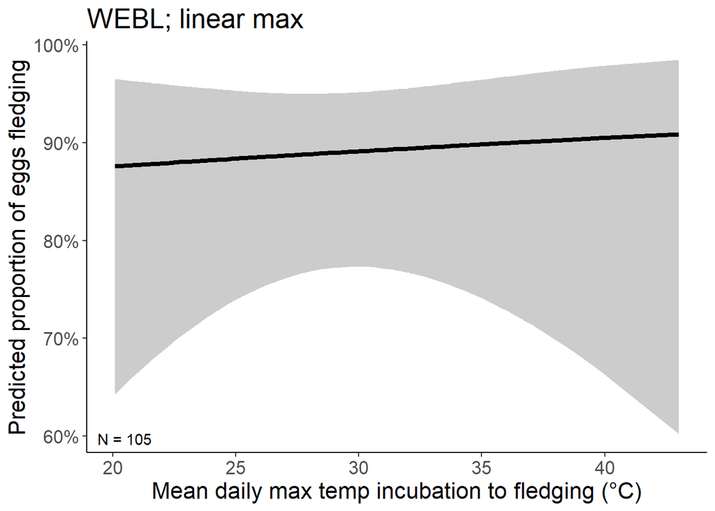

```r
mean_temp <- mean(s_inc_WEBL_noint$data %>% pull(meanmaxt_inc),na.rm = TRUE)
sd_temp <- sd(s_inc_WEBL_noint$data %>% pull(meanmaxt_inc),na.rm = TRUE)


temp_trans <- trans_new("temp_trans",
                          transform = function(x){(x * sd_temp) + mean_temp},
                           inverse = function(x){x})

samp <- s_inc_WEBL_noint$data %>% summarize(count = n())
# samp %>% gt() %>% gtsave("../figures/ss_WEBL.html")


dat_text <- data.frame(
label = paste("N =",samp$count)
)



(pl <- predict_response(s_inc_WEBL_noint,terms = c("meanmaxt_inc_scaled [all]")) %>%
   plot(line_size = 1.5,alpha = .2,show_data = TRUE,limit_range = TRUE) +
   theme_classic() +
   #facet_wrap(~ group, ncol = 2) +
    xlab("Mean daily max temp incubation to fledging (\u00b0C)") +
    ylab("Predicted proportion of eggs fledging") +
   # scale_fill_viridis(discrete = TRUE) +
   #  scale_color_viridis(discrete = TRUE) +
    theme(text = element_text(size = 16)) +
    labs(title = "WEBL; linear max") +
   scale_x_continuous(trans = temp_trans,
                       breaks = c((20-mean_temp)/sd_temp,
                                  (25-mean_temp)/sd_temp,
                                  (30-mean_temp)/sd_temp,
                                  (35-mean_temp)/sd_temp,
                                  (40-mean_temp)/sd_temp#,
                                  #(45-mean_temp)/sd_temp
                                  ),
                       # breaks = c(20,30,40,50),
                       # labels = c("20","30","40","50"),
                       # limits = c((15-mean(g$meanmaxtempI,na.rm = TRUE))/sd(g$meanmaxtempI,na.rm = TRUE),
                       #            (55-mean(g$meanmaxtempI,na.rm = TRUE))/sd(g$meanmaxtempI,na.rm = TRUE))
                       # limits = c(18,5)
                       ) +
   # ylim(0,100) +
   geom_text(data = dat_text, mapping = aes(x = -Inf, y = -Inf,label = label),hjust = -.2,vjust = -.7,inherit.aes = FALSE) +
    theme(legend.position = "none")
 )
```

#### Nestling model

```r
s_nest_WEBL <- glm(cbind(nest_fledged,brood_size - nest_fledged) ~ meanmaxt_nest_scaled * habitat + meanmint_nest_scaled * habitat + juliandate_hatch_scaled + year_fct + site,
               family = binomial(link = "logit"),
               data = dplyr::filter(s,
                                    Species == "WEBL",
                                    !is.na(nest_fledged),
                                    !is.na(brood_size)) %>%
                 mutate(across(c(meanmaxt_nest,meanmint_nest,juliandate_hatch),
                               ~ scale(.x)[,1],
                               .names = "{.col}_scaled")
                      )
               )

s_nest_WEBL_addmax <- glm(cbind(nest_fledged,brood_size - nest_fledged) ~ meanmaxt_nest_scaled + meanmint_nest_scaled * habitat + juliandate_hatch_scaled + year_fct + site,
               family = binomial(link = "logit"),
               data = dplyr::filter(s,
                                    Species == "WEBL",
                                    !is.na(nest_fledged),
                                    !is.na(brood_size)) %>%
                 mutate(across(c(meanmaxt_nest,meanmint_nest,juliandate_hatch),
                               ~ scale(.x)[,1],
                               .names = "{.col}_scaled")
                      )
               )

s_nest_WEBL_addmin <- glm(cbind(nest_fledged,brood_size - nest_fledged) ~ meanmaxt_nest_scaled * habitat + meanmint_nest_scaled + juliandate_hatch_scaled + year_fct + site,
               family = binomial(link = "logit"),
               data = dplyr::filter(s,
                                    Species == "WEBL",
                                    !is.na(nest_fledged),
                                    !is.na(brood_size)) %>%
                 mutate(across(c(meanmaxt_nest,meanmint_nest,juliandate_hatch),
                               ~ scale(.x)[,1],
                               .names = "{.col}_scaled")
                      )
               )
s_nest_WEBL_noint <- glm(cbind(nest_fledged,brood_size - nest_fledged) ~ meanmaxt_nest_scaled + meanmint_nest_scaled + habitat + juliandate_hatch_scaled + year_fct + site,
               family = binomial(link = "logit"),
               data = dplyr::filter(s,
                                    Species == "WEBL",
                                    !is.na(nest_fledged),
                                    !is.na(brood_size)) %>%
                 mutate(across(c(meanmaxt_nest,meanmint_nest,juliandate_hatch),
                               ~ scale(.x)[,1],
                               .names = "{.col}_scaled")
                      )
               )

c1 <- anova(s_nest_WEBL,s_nest_WEBL_addmin,s_nest_WEBL_noint) %>% tibble() %>% mutate(Model = c("no interaction","single interaction","both interacting"),.before = Df)

c2 <- anova(s_nest_WEBL,s_nest_WEBL_addmax,s_nest_WEBL_noint) %>% tibble() %>% mutate(Model = c("no interaction","single interaction","both interacting"),.before = Df)

(tab <- bind_rows(c1,c2) %>%
  as_tibble() %>%
  mutate(across(where(is.numeric),~round(.x,digits = 4)),
         P = `Pr(>Chi)`) %>%
  dplyr::select(Model,Deviance,P) %>%
  mutate(max_or_min = c(rep("Max temp",times = 3),rep("Min temp",times = 3)),
         across(c(Deviance), ~ round(.x, digits = 2)),
         P = if_else(P < 0.001,"<0.001",as.character(P))) %>%
  group_by(max_or_min) %>% gt())
```

| Model | Deviance | P |
| --- | --- | --- |
| Max temp |  |  |
| no interaction | NA | NA |
| single interaction | -7.53 | 0.0568 |
| both interacting | -0.75 | 0.8619 |
| Min temp |  |  |
| no interaction | NA | NA |
| single interaction | -3.37 | 0.3385 |
| both interacting | -4.91 | 0.1785 |

```r
gtsave(tab,"../figures/int_tab_survival_nest_webl.html")
```

```r
summary(s_nest_WEBL_addmin)
```

```
##
## Call:
## glm(formula = cbind(nest_fledged, brood_size - nest_fledged) ~
##     meanmaxt_nest_scaled * habitat + meanmint_nest_scaled + juliandate_hatch_scaled +
##         year_fct + site, family = binomial(link = "logit"), data = dplyr::filter(s,
##     Species == "WEBL", !is.na(nest_fledged), !is.na(brood_size)) %>%
##     mutate(across(c(meanmaxt_nest, meanmint_nest, juliandate_hatch),
##         ~scale(.x)[, 1], .names = "{.col}_scaled")))
##
## Coefficients:
##                                       Estimate Std. Error z value Pr(>|z|)
## (Intercept)                           -0.24419    0.59181  -0.413 0.679888
## meanmaxt_nest_scaled                  -0.45910    0.36381  -1.262 0.206978
## habitatOrchard                         1.97184    0.57610   3.423 0.000620 ***
## habitatGrassland                       3.14972    0.66183   4.759 1.94e-06 ***
## habitatRow crop                        1.79530    0.53033   3.385 0.000711 ***
## meanmint_nest_scaled                   1.01694    0.38439   2.646 0.008154 **
## juliandate_hatch_scaled               -0.70812    0.32426  -2.184 0.028979 *
## year_fct2022                           0.02257    0.52165   0.043 0.965488
## year_fct2023                          -1.00359    0.58670  -1.711 0.087165 .
## sitePG                                 0.89108    0.44909   1.984 0.047233 *
## siteRR                                 0.66376    0.52302   1.269 0.204405
## siteWI                                -0.10297    0.76380  -0.135 0.892756
## meanmaxt_nest_scaled:habitatOrchard   -0.31301    0.43087  -0.726 0.467563
## meanmaxt_nest_scaled:habitatGrassland  0.09076    0.46748   0.194 0.846068
## meanmaxt_nest_scaled:habitatRow crop  -0.07989    0.57883  -0.138 0.890219
## ---
## Signif. codes:  0 '***' 0.001 '**' 0.01 '*' 0.05 '.' 0.1 ' ' 1
##
## (Dispersion parameter for binomial family taken to be 1)
##
##     Null deviance: 262.19  on 77  degrees of freedom
## Residual deviance: 182.08  on 63  degrees of freedom
##   (1 observation deleted due to missingness)
## AIC: 248.24
##
## Number of Fisher Scoring iterations: 5
```

There is a direct effect of min temp in the direction we expect (higher min temp = higher survival).

#### Emtrends to calculate effect of max temp in each habitat

```r
(t <- emtrends(s_nest_WEBL_addmin,specs = pairwise ~ habitat, var = c("meanmaxt_nest_scaled")) %>% test() %>% pluck("emtrends") %>%
   mutate(across(where(is.numeric), ~ round(.x, digits = 3)),
          df = round(df),
          p.value = if_else(p.value == 0.000,"<0.001",as.character(p.value))) %>%
   rename(Habitat = "habitat", `Max temp trend` = "meanmaxt_nest_scaled.trend",Df = "df", `T-ratio` = "z.ratio", P = "p.value") %>%
   gt())
```

| Habitat | Max temp trend | SE | Df | T-ratio | P |
| --- | --- | --- | --- | --- | --- |
| Forest | -0.459 | 0.364 | Inf | -1.262 | 0.207 |
| Orchard | -0.772 | 0.449 | Inf | -1.720 | 0.085 |
| Grassland | -0.368 | 0.454 | Inf | -0.811 | 0.417 |
| Row crop | -0.539 | 0.578 | Inf | -0.933 | 0.351 |

```r
gtsave(t,"../figures/weblsurvival_nest_trendmax.html")

data = s_nest_WEBL_addmin$data

(t <- emmeans(s_nest_WEBL_addmin,specs = ~ habitat,by = c("meanmaxt_nest_scaled"), at = list(meanmaxt_nest_scaled = c(-2,0,2)),type = "response") %>%
    as.tibble() %>% #gt() %>%
  mutate(meanmaxt_nest_scaled = (meanmaxt_nest_scaled * sd(data$meanmaxt_nest,na.rm = TRUE)) + mean(data$meanmaxt_nest,na.rm = TRUE),
    across(where(is.numeric), ~ round(.x, digits = 2)),
    meanmaxt_nest_scaled = round(meanmaxt_nest_scaled),
    meanmaxt_nest_scaled = paste0(meanmaxt_nest_scaled,"\u00b0C")) %>%
  #tibble() %>%
  dplyr::select(-df) %>%
  #mutate(Model = rep(c("TA2 * LU + TA * LU", "TA2 + TA * LU", "TA2 + TA + LU"),2), type = c(rep("Maximum TA", 3),rep("Minimum TA",3)), .before = AIC) %>%
  rename(Habitat = "habitat",`Max temperature` = "meanmaxt_nest_scaled",`Predicted P(survival)` = "prob",`2.5%` = "asymp.LCL",`97.5%` = "asymp.UCL" ) %>%
  group_by(`Max temperature`) %>%
  mutate(row=row_number()) %>%
  pivot_longer(-c(`Max temperature`, row,Habitat)) %>%
  pivot_wider(names_from=c(`Max temperature`, name), values_from=value) %>%
  dplyr::select(-row) %>%
  #mutate(`Maximum TA_P` = if_else(`Maximum TA_P` == 0.000,"<0.001",as.character(`Maximum TA_P`))) %>%
  #mutate(`Minimum TA_P` = if_else(`Minimum TA_P` == 0.000,"<0.001",as.character(`Minimum TA_P`))) %>%
  gt() %>% tab_options(data_row.padding = px(1)) %>%
  tab_spanner_delim(
    delim="_"
  ))
```

| Habitat | 23°C Predicted P(survival) | 23°C SE | 23°C 2.5% | 23°C 97.5% | 31°C Predicted P(survival) | 31°C SE | 31°C 2.5% | 31°C 97.5% | 40°C Predicted P(survival) | 40°C SE | 40°C 2.5% | 40°C 97.5% |
| --- | --- | --- | --- | --- | --- | --- | --- | --- | --- | --- | --- | --- |
| Forest | 0.67 | 0.15 | 0.36 | 0.89 | 0.45 | 0.08 | 0.31 | 0.60 | 0.25 | 0.17 | 0.05 | 0.66 |
| Orchard | 0.97 | 0.04 | 0.78 | 1.00 | 0.86 | 0.05 | 0.72 | 0.93 | 0.56 | 0.23 | 0.17 | 0.89 |
| Grassland | 0.98 | 0.03 | 0.78 | 1.00 | 0.95 | 0.03 | 0.86 | 0.98 | 0.90 | 0.08 | 0.61 | 0.98 |
| Row crop | 0.94 | 0.08 | 0.49 | 1.00 | 0.83 | 0.07 | 0.66 | 0.93 | 0.63 | 0.26 | 0.16 | 0.94 |

```r
gtsave(t,"../figures/weblsurvival_nest_deltamax.html")

((emmeans(s_nest_WEBL_addmin,specs = ~ habitat,by = c("meanmaxt_nest_scaled"), at = list(meanmaxt_nest_scaled = c(2))) %>% as.tibble() %>% pull(emmean))-(emmeans(s_nest_WEBL_addmin,specs = ~ habitat,by = c("meanmaxt_nest_scaled"), at = list(meanmaxt_nest_scaled = c(-2))) %>% as.tibble() %>% pull(emmean)))/(emmeans(s_nest_WEBL_addmin,specs = ~ habitat,by = c("meanmaxt_nest_scaled"), at = list(meanmaxt_nest_scaled = c(-2))) %>% as.tibble() %>% pull(emmean))
```

```
## [1] -2.5247640 -0.9287916 -0.3986875 -0.8037362
```

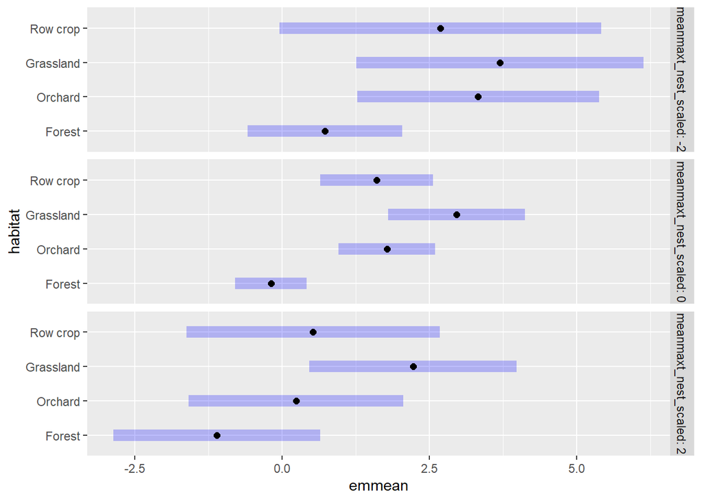

```r
emmeans(s_nest_WEBL_addmin,specs = pairwise ~ habitat,by = c("meanmaxt_nest_scaled"), at = list(meanmaxt_nest_scaled = c(-2,0,2))) %>% plot()
```

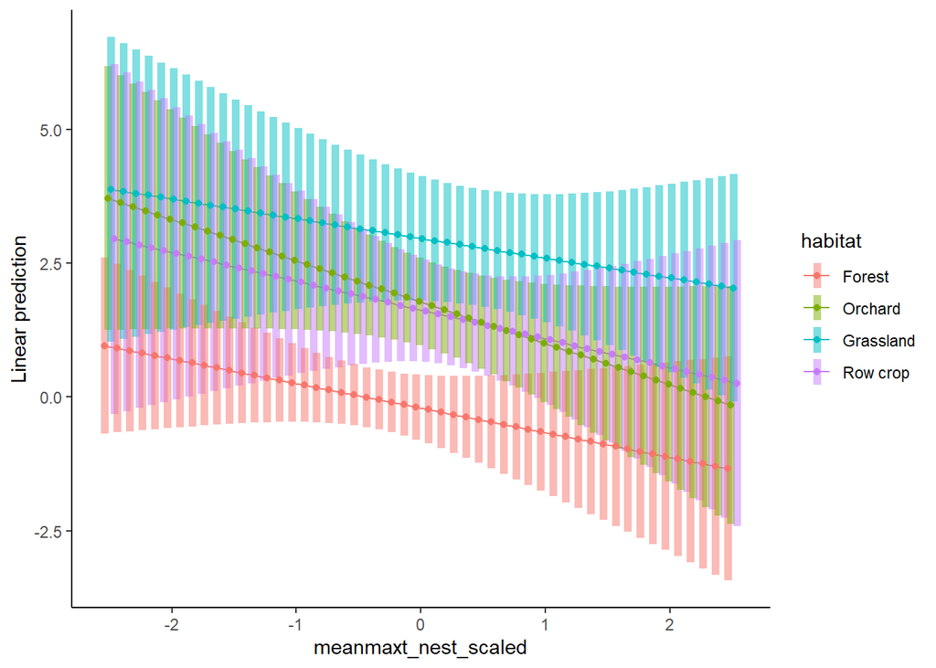

```r
emmip(s_nest_WEBL_addmin,formula = habitat ~ meanmaxt_nest_scaled, at = list(meanmaxt_nest_scaled = seq(from = -2.5, to = 2.5, by = .1)),CIs = TRUE, plotit = FALSE) %>% emmip_ggplot() + theme_classic()
```

## Emmeans to check for effect of habitat

```r
(t <- emmeans(s_nest_WEBL_addmin,"habitat") %>% pairs() %>% as_tibble() %>%
   mutate(across(estimate:z.ratio,~round(.x,digits = 2)),
          across(p.value,~round(.x,digits = 3))) %>% gt())
```

| contrast | estimate | SE | df | z.ratio | p.value |
| --- | --- | --- | --- | --- | --- |
| Forest - Orchard | -1.97 | 0.58 | Inf | -3.42 | 0.003 |
| Forest - Grassland | -3.15 | 0.66 | Inf | -4.76 | 0.000 |
| Forest - Row crop | -1.80 | 0.53 | Inf | -3.39 | 0.004 |
| Orchard - Grassland | -1.18 | 0.78 | Inf | -1.51 | 0.431 |
| Orchard - Row crop | 0.18 | 0.68 | Inf | 0.26 | 0.994 |
| Grassland - Row crop | 1.35 | 0.75 | Inf | 1.80 | 0.272 |

```r
gtsave(t,"../figures/survival_nest_byhabitat_webl.html")
```

### Check for effect of temperature

```r
(t <- summary(s_nest_WEBL_noint) %>% coef() %>% as_tibble(rownames = "Covariate") %>%
   # dplyr::filter(Covariate != "poly(mean_temp_scaled, 2)1") %>%
   mutate(across(Estimate:`z value`,~round(.x,digits = 2)),
          across(`Pr(>|z|)`,~round(.x,digits = 3))) %>% gt())
```

| Covariate | Estimate | Std. Error | z value | Pr(>\|z\|) |
| --- | --- | --- | --- | --- |
| (Intercept) | -0.26 | 0.57 | -0.46 | 0.647 |
| meanmaxt_nest_scaled | -0.51 | 0.31 | -1.62 | 0.104 |
| meanmint_nest_scaled | 0.99 | 0.37 | 2.63 | 0.009 |
| habitatOrchard | 1.96 | 0.56 | 3.50 | 0.000 |
| habitatGrassland | 3.24 | 0.66 | 4.90 | 0.000 |
| habitatRow crop | 1.81 | 0.50 | 3.66 | 0.000 |
| juliandate_hatch_scaled | -0.72 | 0.32 | -2.27 | 0.023 |
| year_fct2022 | 0.03 | 0.51 | 0.05 | 0.956 |
| year_fct2023 | -1.08 | 0.57 | -1.88 | 0.060 |
| sitePG | 0.92 | 0.44 | 2.09 | 0.037 |
| siteRR | 0.66 | 0.51 | 1.29 | 0.198 |
| siteWI | -0.10 | 0.75 | -0.13 | 0.898 |

```r
gtsave(t,"../figures/survival_nest_byhabitat_summary_webl.html")
```

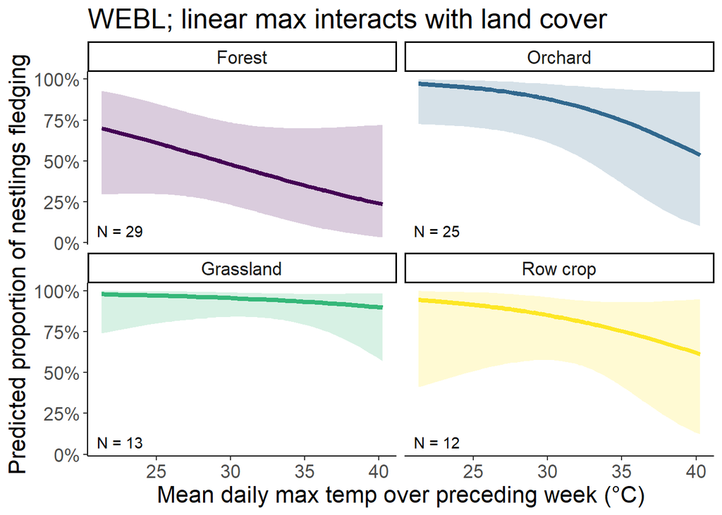

```r
data = s_nest_WEBL_addmin$data


mean_temp <- mean(data %>% pull(meanmaxt_nest),na.rm = TRUE)
sd_temp <- sd(data %>% pull(meanmaxt_nest),na.rm = TRUE)


temp_trans <- trans_new("temp_trans",
                          transform = function(x){(x * sd_temp) + mean_temp},
                          inverse = function(x){x})

samp <- data %>% group_by(habitat) %>% summarize(count = n())
# samp %>% gt() %>% gtsave("../figures/ss_webl.html")


dat_text <- data.frame(
  label = paste("N =",samp$count),
  group   = factor(samp$habitat)
)

(pl <- predict_response(s_nest_WEBL_addmin,terms = c("meanmaxt_nest_scaled [all]","habitat")) %>%
   plot(line_size = 1.5,alpha = .2,show_data = TRUE,limit_range = TRUE) +
    theme_classic() +
   facet_wrap(~ group, ncol = 2) +
    xlab("Mean daily max temp over preceding week (\u00b0C)") +
    ylab("Predicted proportion of nestlings fledging") +
   scale_fill_viridis(discrete = TRUE) +
    scale_color_viridis(discrete = TRUE) +
    theme(text = element_text(size = 16)) +
    labs(title = "WEBL; linear max interacts with land cover") +
   scale_x_continuous(trans = temp_trans,
                       breaks = c((20-mean_temp)/sd_temp,
                                  (25-mean_temp)/sd_temp,
                                  (30-mean_temp)/sd_temp,
                                  (35-mean_temp)/sd_temp,
                                  (40-mean_temp)/sd_temp#,
                                  #(45-mean_temp)/sd_temp
                                  ),
                       # breaks = c(20,30,40,50),
                       # labels = c("20","30","40","50"),
                       # limits = c((15-mean(g$meanmaxtempI,na.rm = TRUE))/sd(g$meanmaxtempI,na.rm = TRUE),
                       #            (55-mean(g$meanmaxtempI,na.rm = TRUE))/sd(g$meanmaxtempI,na.rm = TRUE))
                       # limits = c(18,5)
                       ) +
   # ylim(0,100) +
   geom_text(data = dat_text, mapping = aes(x = -Inf, y = -Inf,label = label),hjust = -.2,vjust = -.7,inherit.aes = FALSE) +
    theme(legend.position = "none")
   )
```

#### Nest period model

```r
s_nestpd_WEBL <- glm(cbind(nest_fledged,clutch_size - nest_fledged) ~ meanmaxt_nestpd_scaled * habitat + meanmint_nestpd_scaled * habitat + juliandate_hatch_scaled + year_fct + site,
               family = binomial(link = "logit"),
               data = dplyr::filter(s,
                                    Species == "WEBL",
                                    !is.na(nest_fledged),
                                    !is.na(clutch_size)) %>%
                 mutate(across(c(meanmaxt_nestpd,meanmint_nestpd,juliandate_hatch),
                               ~ scale(.x)[,1],
                               .names = "{.col}_scaled")
                      )
               )

s_nestpd_WEBL_addmax <- glm(cbind(nest_fledged,clutch_size - nest_fledged) ~ meanmaxt_nestpd_scaled + meanmint_nestpd_scaled * habitat + juliandate_hatch_scaled + year_fct + site,
               family = binomial(link = "logit"),
               data = dplyr::filter(s,
                                    Species == "WEBL",
                                    !is.na(nest_fledged),
                                    !is.na(clutch_size)) %>%
                 mutate(across(c(meanmaxt_nestpd,meanmint_nestpd,juliandate_hatch),
                               ~ scale(.x)[,1],
                               .names = "{.col}_scaled")
                      )
               )

s_nestpd_WEBL_addmin <- glm(cbind(nest_fledged,clutch_size - nest_fledged) ~ meanmaxt_nestpd_scaled * habitat + meanmint_nestpd_scaled + juliandate_hatch_scaled + year_fct + site,
               family = binomial(link = "logit"),
               data = dplyr::filter(s,
                                    Species == "WEBL",
                                    !is.na(nest_fledged),
                                    !is.na(clutch_size)) %>%
                 mutate(across(c(meanmaxt_nestpd,meanmint_nestpd,juliandate_hatch),
                               ~ scale(.x)[,1],
                               .names = "{.col}_scaled")
                      )
               )
s_nestpd_WEBL_noint <- glm(cbind(nest_fledged,clutch_size - nest_fledged) ~ meanmaxt_nestpd_scaled + meanmint_nestpd_scaled + habitat + juliandate_hatch_scaled + year_fct + site,
               family = binomial(link = "logit"),
               data = dplyr::filter(s,
                                    Species == "WEBL",
                                    !is.na(nest_fledged),
                                    !is.na(clutch_size)) %>%
                 mutate(across(c(meanmaxt_nestpd,meanmint_nestpd,juliandate_hatch),
                               ~ scale(.x)[,1],
                               .names = "{.col}_scaled")
                      )
               )

c1 <- anova(s_nestpd_WEBL,s_nestpd_WEBL_addmin,s_nestpd_WEBL_noint) %>% tibble() %>% mutate(Model = c("no interaction","single interaction","both interacting"),.before = Df)

c2 <- anova(s_nestpd_WEBL,s_nestpd_WEBL_addmax,s_nestpd_WEBL_noint) %>% tibble() %>% mutate(Model = c("no interaction","single interaction","both interacting"),.before = Df)

(tab <- bind_rows(c1,c2) %>%
  as_tibble() %>%
  mutate(across(where(is.numeric),~round(.x,digits = 4)),
         P = `Pr(>Chi)`) %>%
  dplyr::select(Model,Deviance,P) %>%
  mutate(max_or_min = c(rep("Max temp",times = 3),rep("Min temp",times = 3)),
         across(c(Deviance), ~ round(.x, digits = 2)),
         P = if_else(P < 0.001,"<0.001",as.character(P))) %>%
  group_by(max_or_min) %>% gt())
```

| Model | Deviance | P |
| --- | --- | --- |
| Max temp |  |  |
| no interaction | NA | NA |
| single interaction | -14.06 | 0.0028 |
| both interacting | -0.75 | 0.861 |
| Min temp |  |  |
| no interaction | NA | NA |
| single interaction | -12.26 | 0.0065 |
| both interacting | -2.55 | 0.4659 |

```r
gtsave(tab,"../figures/int_tab_survival_nestpd_webl.html")
```

```r
summary(s_nestpd_WEBL_addmin)
```

```
##
## Call:
## glm(formula = cbind(nest_fledged, clutch_size - nest_fledged) ~
##     meanmaxt_nestpd_scaled * habitat + meanmint_nestpd_scaled +
##         juliandate_hatch_scaled + year_fct + site, family = binomial(link = "logit"),
##     data = dplyr::filter(s, Species == "WEBL", !is.na(nest_fledged),
##         !is.na(clutch_size)) %>% mutate(across(c(meanmaxt_nestpd,
##         meanmint_nestpd, juliandate_hatch), ~scale(.x)[, 1],
##         .names = "{.col}_scaled")))
##
## Coefficients:
##                                          Estimate Std. Error z value Pr(>|z|)
## (Intercept)                              0.004090   0.441474   0.009 0.992608
## meanmaxt_nestpd_scaled                  -0.631321   0.355132  -1.778 0.075452
## habitatOrchard                           1.589944   0.428458   3.711 0.000207
## habitatGrassland                         2.533201   0.531701   4.764 1.89e-06
## habitatRow crop                          1.433855   0.410256   3.495 0.000474
## meanmint_nestpd_scaled                   0.547311   0.287337   1.905 0.056810
## juliandate_hatch_scaled                 -0.082304   0.285650  -0.288 0.773249
## year_fct2022                            -0.339458   0.392049  -0.866 0.386570
## year_fct2023                            -1.069412   0.498787  -2.144 0.032031
## sitePG                                   0.383874   0.365199   1.051 0.293196
## siteRR                                   0.353190   0.424149   0.833 0.405013
## siteWI                                  -0.776437   0.564390  -1.376 0.168911
## meanmaxt_nestpd_scaled:habitatOrchard   -0.005431   0.315857  -0.017 0.986281
## meanmaxt_nestpd_scaled:habitatGrassland  0.236014   0.402762   0.586 0.557883
## meanmaxt_nestpd_scaled:habitatRow crop  -0.172339   0.432563  -0.398 0.690325
##
## (Intercept)
## meanmaxt_nestpd_scaled                  .
## habitatOrchard                          ***
## habitatGrassland                        ***
## habitatRow crop                         ***
## meanmint_nestpd_scaled                  .
## juliandate_hatch_scaled
## year_fct2022
## year_fct2023                            *
## sitePG
## siteRR
## siteWI
## meanmaxt_nestpd_scaled:habitatOrchard
## meanmaxt_nestpd_scaled:habitatGrassland
## meanmaxt_nestpd_scaled:habitatRow crop
## ---
## Signif. codes:  0 '***' 0.001 '**' 0.01 '*' 0.05 '.' 0.1 ' ' 1
##
## (Dispersion parameter for binomial family taken to be 1)
##
##     Null deviance: 258.83  on 78  degrees of freedom
## Residual deviance: 197.02  on 64  degrees of freedom
## AIC: 304.33
##
## Number of Fisher Scoring iterations: 4
```

There is a direct effect of min temp in the direction we expect (higher min temp = higher survival).

#### Emtrends to calculate effect of max temp in each habitat

```r
(t <- emtrends(s_nestpd_WEBL_addmin,specs = pairwise ~ habitat, var = c("meanmaxt_nestpd_scaled")) %>% test() %>% pluck("emtrends") %>%
   mutate(across(where(is.numeric), ~ round(.x, digits = 3)),
          df = round(df),
          p.value = if_else(p.value == 0.000,"<0.001",as.character(p.value))) %>%
   rename(Habitat = "habitat", `Max temp trend` = "meanmaxt_nestpd_scaled.trend",Df = "df", `T-ratio` = "z.ratio", P = "p.value") %>%
   gt())
```

| Habitat | Max temp trend | SE | Df | T-ratio | P |
| --- | --- | --- | --- | --- | --- |
| Forest | -0.631 | 0.355 | Inf | -1.778 | 0.075 |
| Orchard | -0.637 | 0.389 | Inf | -1.635 | 0.102 |
| Grassland | -0.395 | 0.389 | Inf | -1.016 | 0.31 |
| Row crop | -0.804 | 0.455 | Inf | -1.765 | 0.078 |

```r
gtsave(t,"../figures/weblsurvival_nestpd_trendmax.html")

data = s_nestpd_WEBL_addmin$data

(t <- emmeans(s_nestpd_WEBL_addmin,specs = ~ habitat,by = c("meanmaxt_nestpd_scaled"), at = list(meanmaxt_nestpd_scaled = c(-2,0,2)),type = "response") %>%
    as.tibble() %>% #gt() %>%
  mutate(meanmaxt_nestpd_scaled = (meanmaxt_nestpd_scaled * sd(data$meanmaxt_nestpd,na.rm = TRUE)) + mean(data$meanmaxt_nestpd,na.rm = TRUE),
    across(where(is.numeric), ~ round(.x, digits = 2)),
    meanmaxt_nestpd_scaled = round(meanmaxt_nestpd_scaled),
    meanmaxt_nestpd_scaled = paste0(meanmaxt_nestpd_scaled,"\u00b0C")) %>%
  #tibble() %>%
  dplyr::select(-df) %>%
  #mutate(Model = rep(c("TA2 * LU + TA * LU", "TA2 + TA * LU", "TA2 + TA + LU"),2), type = c(rep("Maximum TA", 3),rep("Minimum TA",3)), .before = AIC) %>%
  rename(Habitat = "habitat",`Max temperature` = "meanmaxt_nestpd_scaled",`Predicted P(survival)` = "prob",`2.5%` = "asymp.LCL",`97.5%` = "asymp.UCL" ) %>%
  group_by(`Max temperature`) %>%
  mutate(row=row_number()) %>%
  pivot_longer(-c(`Max temperature`, row,Habitat)) %>%
  pivot_wider(names_from=c(`Max temperature`, name), values_from=value) %>%
  dplyr::select(-row) %>%
  #mutate(`Maximum TA_P` = if_else(`Maximum TA_P` == 0.000,"<0.001",as.character(`Maximum TA_P`))) %>%
  #mutate(`Minimum TA_P` = if_else(`Minimum TA_P` == 0.000,"<0.001",as.character(`Minimum TA_P`))) %>%
  gt() %>% tab_options(data_row.padding = px(1)) %>%
  tab_spanner_delim(
    delim="_"
  ))
```

| Habitat | 22°C Predicted P(survival) | 22°C SE | 22°C 2.5% | 22°C 97.5% | 31°C Predicted P(survival) | 31°C SE | 31°C 2.5% | 31°C 97.5% | 39°C Predicted P(survival) | 39°C SE | 39°C 2.5% | 39°C 97.5% |
| --- | --- | --- | --- | --- | --- | --- | --- | --- | --- | --- | --- | --- |
| Forest | 0.69 | 0.14 | 0.38 | 0.89 | 0.38 | 0.06 | 0.28 | 0.50 | 0.15 | 0.11 | 0.03 | 0.48 |
| Orchard | 0.92 | 0.06 | 0.68 | 0.98 | 0.75 | 0.06 | 0.63 | 0.85 | 0.46 | 0.21 | 0.14 | 0.81 |
| Grassland | 0.95 | 0.06 | 0.68 | 0.99 | 0.89 | 0.05 | 0.76 | 0.95 | 0.78 | 0.12 | 0.47 | 0.93 |
| Row crop | 0.93 | 0.07 | 0.61 | 0.99 | 0.72 | 0.07 | 0.56 | 0.84 | 0.34 | 0.20 | 0.09 | 0.74 |

```r
gtsave(t,"../figures/weblsurvival_nestpd_deltamax.html")

((emmeans(s_nestpd_WEBL_addmin,specs = ~ habitat,by = c("meanmaxt_nestpd_scaled"), at = list(meanmaxt_nestpd_scaled = c(2))) %>% as.tibble() %>% pull(emmean))-(emmeans(s_nestpd_WEBL_addmin,specs = ~ habitat,by = c("meanmaxt_nestpd_scaled"), at = list(meanmaxt_nestpd_scaled = c(-2))) %>% as.tibble() %>% pull(emmean)))/(emmeans(s_nestpd_WEBL_addmin,specs = ~ habitat,by = c("meanmaxt_nestpd_scaled"), at = list(meanmaxt_nestpd_scaled = c(-2))) %>% as.tibble() %>% pull(emmean))
```

```
## [1] -3.2076646 -1.0665551 -0.5551215 -1.2528812
```

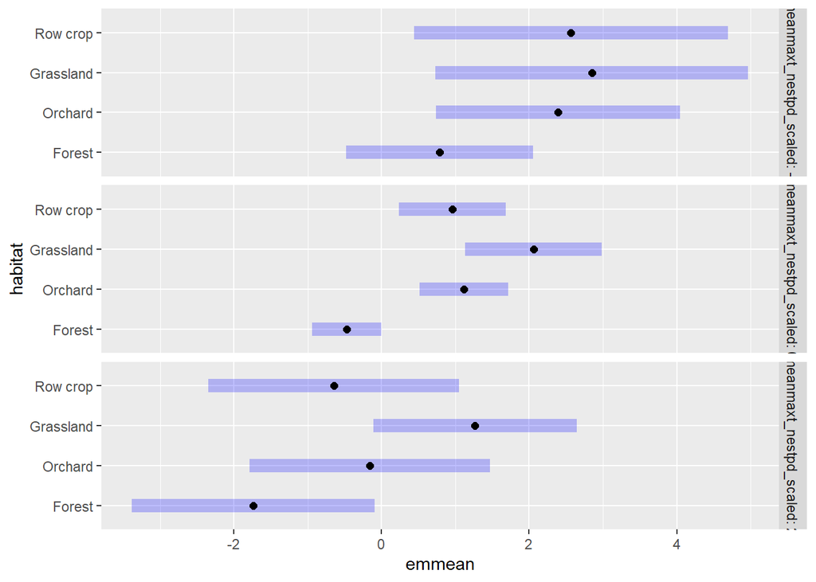

```r
emmeans(s_nestpd_WEBL_addmin,specs = pairwise ~ habitat,by = c("meanmaxt_nestpd_scaled"), at = list(meanmaxt_nestpd_scaled = c(-2,0,2))) %>% plot()
```

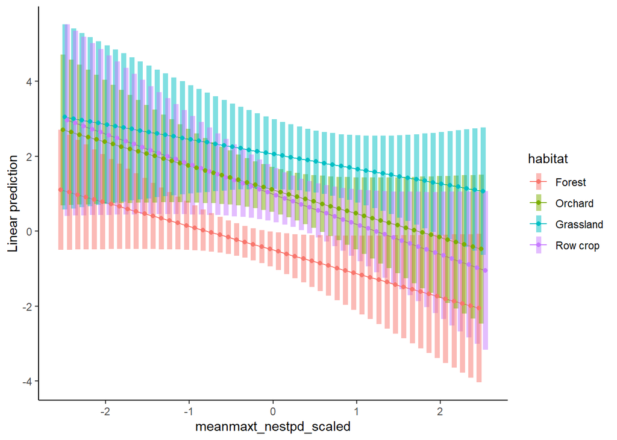

```r
emmip(s_nestpd_WEBL_addmin,formula = habitat ~ meanmaxt_nestpd_scaled, at = list(meanmaxt_nestpd_scaled = seq(from = -2.5, to = 2.5, by = .1)),CIs = TRUE, plotit = FALSE) %>% emmip_ggplot() + theme_classic()
```

## Emmeans to check for effect of habitat

```r
(t <- emmeans(s_nestpd_WEBL_addmin,"habitat") %>% pairs() %>% as_tibble() %>%
   mutate(across(estimate:z.ratio,~round(.x,digits = 2)),
          across(p.value,~round(.x,digits = 3))) %>% gt())
```

| contrast | estimate | SE | df | z.ratio | p.value |
| --- | --- | --- | --- | --- | --- |
| Forest - Orchard | -1.59 | 0.43 | Inf | -3.71 | 0.001 |
| Forest - Grassland | -2.53 | 0.53 | Inf | -4.76 | 0.000 |
| Forest - Row crop | -1.43 | 0.41 | Inf | -3.50 | 0.003 |
| Orchard - Grassland | -0.94 | 0.60 | Inf | -1.56 | 0.402 |
| Orchard - Row crop | 0.16 | 0.50 | Inf | 0.31 | 0.990 |
| Grassland - Row crop | 1.10 | 0.59 | Inf | 1.86 | 0.244 |

```r
gtsave(t,"../figures/survival_nestpd_byhabitat_webl.html")
```

Forest survival is lower than in the other land covers.

### Check for effect of temperature

```r
(t <- summary(s_nestpd_WEBL_noint) %>% coef() %>% as_tibble(rownames = "Covariate") %>%
   # dplyr::filter(Covariate != "poly(mean_temp_scaled, 2)1") %>%
   mutate(across(Estimate:`z value`,~round(.x,digits = 2)),
          across(`Pr(>|z|)`,~round(.x,digits = 3))) %>% gt())
```

| Covariate | Estimate | Std. Error | z value | Pr(>\|z\|) |
| --- | --- | --- | --- | --- |
| (Intercept) | 0.01 | 0.43 | 0.01 | 0.988 |
| meanmaxt_nestpd_scaled | -0.58 | 0.30 | -1.93 | 0.054 |
| meanmint_nestpd_scaled | 0.51 | 0.28 | 1.82 | 0.069 |
| habitatOrchard | 1.56 | 0.42 | 3.72 | 0.000 |
| habitatGrassland | 2.61 | 0.54 | 4.86 | 0.000 |
| habitatRow crop | 1.34 | 0.38 | 3.52 | 0.000 |
| juliandate_hatch_scaled | -0.08 | 0.28 | -0.29 | 0.770 |
| year_fct2022 | -0.33 | 0.38 | -0.86 | 0.390 |
| year_fct2023 | -1.10 | 0.49 | -2.22 | 0.026 |
| sitePG | 0.43 | 0.36 | 1.18 | 0.238 |
| siteRR | 0.35 | 0.41 | 0.85 | 0.397 |
| siteWI | -0.74 | 0.56 | -1.31 | 0.189 |

```r
gtsave(t,"../figures/survival_nestpd_byhabitat_summary_webl.html")
```

Hot temps and low temps reduce survival overall.

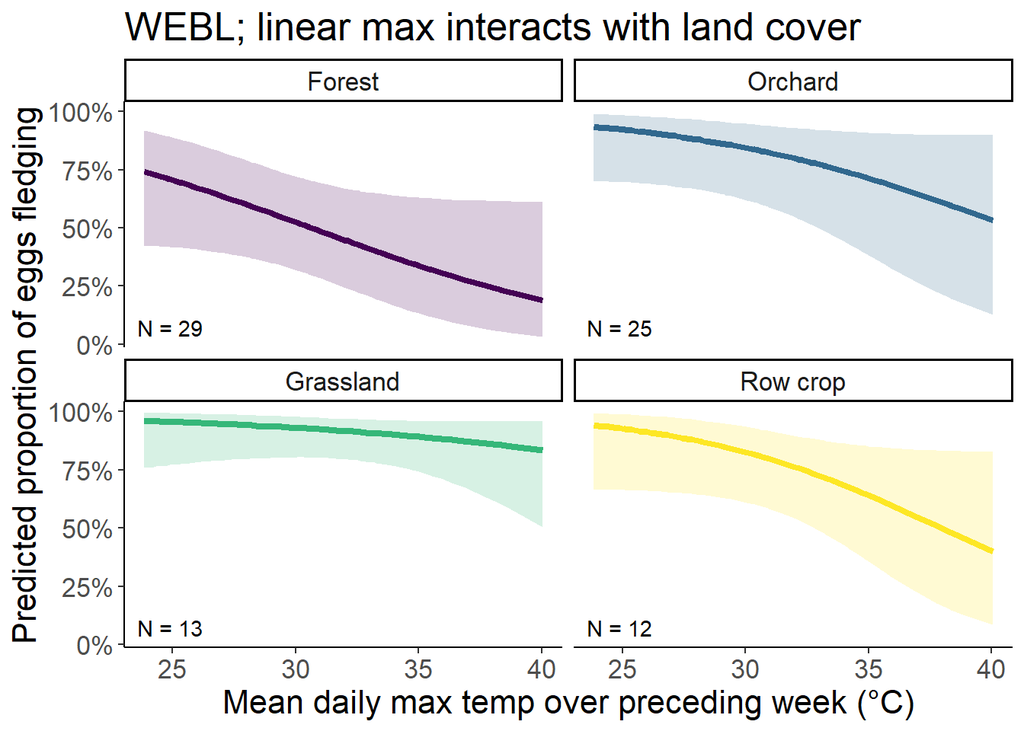

```r
data = s_nestpd_WEBL_addmin$data


mean_temp <- mean(data %>% pull(meanmaxt_nestpd),na.rm = TRUE)
sd_temp <- sd(data %>% pull(meanmaxt_nestpd),na.rm = TRUE)


temp_trans <- trans_new("temp_trans",
                          transform = function(x){(x * sd_temp) + mean_temp},
                          inverse = function(x){x})

samp <- data %>% group_by(habitat) %>% summarize(count = n())
# samp %>% gt() %>% gtsave("../figures/ss_webl.html")


dat_text <- data.frame(
  label = paste("N =",samp$count),
  group   = factor(samp$habitat)
)

(pl <- predict_response(s_nestpd_WEBL_addmin,terms = c("meanmaxt_nestpd_scaled [all]","habitat")) %>%
   plot(line_size = 1.5,alpha = .2,show_data = TRUE,limit_range = TRUE) +
    theme_classic() +
   facet_wrap(~ group, ncol = 2) +
    xlab("Mean daily max temp over preceding week (\u00b0C)") +
    ylab("Predicted proportion of eggs fledging") +
   scale_fill_viridis(discrete = TRUE) +
    scale_color_viridis(discrete = TRUE) +
    theme(text = element_text(size = 16)) +
    labs(title = "WEBL; linear max interacts with land cover") +
   scale_x_continuous(trans = temp_trans,
                       breaks = c((20-mean_temp)/sd_temp,
                                  (25-mean_temp)/sd_temp,
                                  (30-mean_temp)/sd_temp,
                                  (35-mean_temp)/sd_temp,
                                  (40-mean_temp)/sd_temp#,
                                  #(45-mean_temp)/sd_temp
                                  ),
                       # breaks = c(20,30,40,50),
                       # labels = c("20","30","40","50"),
                       # limits = c((15-mean(g$meanmaxtempI,na.rm = TRUE))/sd(g$meanmaxtempI,na.rm = TRUE),
                       #            (55-mean(g$meanmaxtempI,na.rm = TRUE))/sd(g$meanmaxtempI,na.rm = TRUE))
                       # limits = c(18,5)
                       ) +
   # ylim(0,100) +
   geom_text(data = dat_text, mapping = aes(x = -Inf, y = -Inf,label = label),hjust = -.2,vjust = -.7,inherit.aes = FALSE) +
    theme(legend.position = "none")
   )
```

### TRES

#### Incubation model

```r
s_inc_TRES <- glm(cbind(eggs_hatched,clutch_size - eggs_hatched) ~ meanmaxt_inc_scaled * habitat + meanmint_inc_scaled * habitat + juliandate_inc_scaled + year_fct + site,
               family = binomial(link = "logit"),
               data = dplyr::filter(s,
                                    Species == "TRES",
                                    !is.na(eggs_hatched),
                                    !is.na(clutch_size)) %>%
                 mutate(across(c(meanmaxt_inc,meanmint_inc,juliandate_inc),
                               ~ scale(.x)[,1],
                               .names = "{.col}_scaled")
                      )
               )

s_inc_TRES_addmax <- glm(cbind(eggs_hatched,clutch_size - eggs_hatched) ~ meanmaxt_inc_scaled + meanmint_inc_scaled * habitat + juliandate_inc_scaled + year_fct + site,
               family = binomial(link = "logit"),
               data = dplyr::filter(s,
                                    Species == "TRES",
                                    !is.na(eggs_hatched),
                                    !is.na(clutch_size)) %>%
                 mutate(across(c(meanmaxt_inc,meanmint_inc,juliandate_inc),
                               ~ scale(.x)[,1],
                               .names = "{.col}_scaled")
                      )
               )

s_inc_TRES_addmin <- glm(cbind(eggs_hatched,clutch_size - eggs_hatched) ~ meanmaxt_inc_scaled * habitat + meanmint_inc_scaled + juliandate_inc_scaled + year_fct + site,
               family = binomial(link = "logit"),
               data = dplyr::filter(s,
                                    Species == "TRES",
                                    !is.na(eggs_hatched),
                                    !is.na(clutch_size)) %>%
                 mutate(across(c(meanmaxt_inc,meanmint_inc,juliandate_inc),
                               ~ scale(.x)[,1],
                               .names = "{.col}_scaled")
                      )
               )
s_inc_TRES_noint <- glm(cbind(eggs_hatched,clutch_size - eggs_hatched) ~ meanmaxt_inc_scaled + meanmint_inc_scaled + habitat + juliandate_inc_scaled + year_fct + site,
               family = binomial(link = "logit"),
               data = dplyr::filter(s,
                                    Species == "TRES",
                                    !is.na(eggs_hatched),
                                    !is.na(clutch_size)) %>%
                 mutate(across(c(meanmaxt_inc,meanmint_inc,juliandate_inc),
                               ~ scale(.x)[,1],
                               .names = "{.col}_scaled")
                      )
               )

c1 <- anova(s_inc_TRES,s_inc_TRES_addmin,s_inc_TRES_noint) %>% tibble() %>% mutate(Model = c("no interaction","single interaction","both interacting"),.before = Df)

c2 <- anova(s_inc_TRES,s_inc_TRES_addmax,s_inc_TRES_noint) %>% tibble() %>% mutate(Model = c("no interaction","single interaction","both interacting"),.before = Df)

(tab <- bind_rows(c1,c2) %>%
  as_tibble() %>%
  mutate(across(where(is.numeric),~round(.x,digits = 4)),
         P = `Pr(>Chi)`) %>%
  dplyr::select(Model,Deviance,P) %>%
  mutate(max_or_min = c(rep("Max temp",times = 3),rep("Min temp",times = 3)),
         across(c(Deviance), ~ round(.x, digits = 2)),
         P = if_else(P < 0.001,"<0.001",as.character(P))) %>%
  group_by(max_or_min) %>% gt())
```

| Model | Deviance | P |
| --- | --- | --- |
| Max temp |  |  |
| no interaction | NA | NA |
| single interaction | -2.60 | 0.4583 |
| both interacting | -2.90 | 0.4076 |
| Min temp |  |  |
| no interaction | NA | NA |
| single interaction | -2.13 | 0.5458 |
| both interacting | -3.36 | 0.3389 |

```r
gtsave(tab,"../figures/int_tab_survival_tres.html")
```

Land cover does not interact with max or min temp during incubation.

```r
summary(s_inc_TRES_noint)
```

```
##
## Call:
## glm(formula = cbind(eggs_hatched, clutch_size - eggs_hatched) ~
##     meanmaxt_inc_scaled + meanmint_inc_scaled + habitat + juliandate_inc_scaled +
##         year_fct + site, family = binomial(link = "logit"), data = dplyr::filter(s,
##     Species == "TRES", !is.na(eggs_hatched), !is.na(clutch_size)) %>%
##     mutate(across(c(meanmaxt_inc, meanmint_inc, juliandate_inc),
##         ~scale(.x)[, 1], .names = "{.col}_scaled")))
##
## Coefficients:
##                       Estimate Std. Error z value Pr(>|z|)
## (Intercept)            1.66039    0.39172   4.239 2.25e-05 ***
## meanmaxt_inc_scaled   -0.41101    0.18348  -2.240  0.02508 *
## meanmint_inc_scaled    0.12351    0.26616   0.464  0.64262
## habitatOrchard         0.10335    0.89881   0.115  0.90845
## habitatGrassland       1.46968    0.49839   2.949  0.00319 **
## habitatRow crop        0.94368    0.45561   2.071  0.03833 *
## juliandate_inc_scaled  0.13742    0.25446   0.540  0.58917
## year_fct2022          -0.13968    0.40524  -0.345  0.73033
## year_fct2023          -0.30468    0.46696  -0.652  0.51410
## sitePG                -0.42585    0.46820  -0.910  0.36307
## siteRR                -0.74419    0.43268  -1.720  0.08544 .
## siteWI                 0.08997    1.08625   0.083  0.93399
## ---
## Signif. codes:  0 '***' 0.001 '**' 0.01 '*' 0.05 '.' 0.1 ' ' 1
##
## (Dispersion parameter for binomial family taken to be 1)
##
##     Null deviance: 100.386  on 83  degrees of freedom
## Residual deviance:  84.675  on 72  degrees of freedom
##   (1 observation deleted due to missingness)
## AIC: 176.08
##
## Number of Fisher Scoring iterations: 5
```

However, there is a direct negative effect of high temps. Also, survival is generally higher in Grassland and Row crop than Forest.

```r
(t <- emmeans(s_inc_TRES_noint,"habitat") %>% pairs() %>% as_tibble() %>%
   mutate(across(estimate:z.ratio,~round(.x,digits = 2)),
          across(p.value,~round(.x,digits = 3))) %>% gt())
```

| contrast | estimate | SE | df | z.ratio | p.value |
| --- | --- | --- | --- | --- | --- |
| Forest - Orchard | -0.10 | 0.90 | Inf | -0.11 | 0.999 |
| Forest - Grassland | -1.47 | 0.50 | Inf | -2.95 | 0.017 |
| Forest - Row crop | -0.94 | 0.46 | Inf | -2.07 | 0.163 |
| Orchard - Grassland | -1.37 | 0.81 | Inf | -1.69 | 0.329 |
| Orchard - Row crop | -0.84 | 0.83 | Inf | -1.01 | 0.746 |
| Grassland - Row crop | 0.53 | 0.48 | Inf | 1.10 | 0.687 |

```r
gtsave(t,"../figures/survival_inc_byhabitat_tres.html")
```

Posthoc test does not support the difference between row crop and forest?

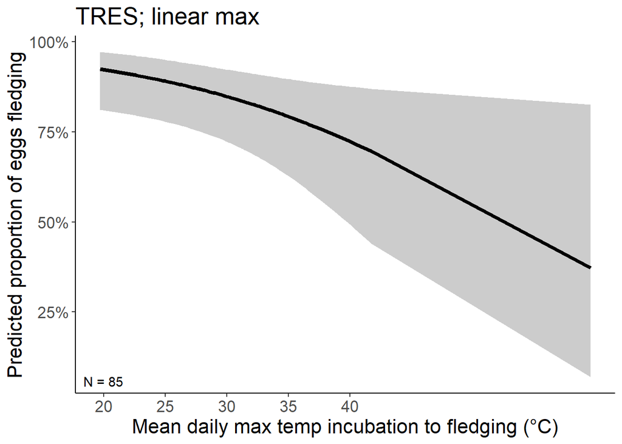

```r
mean_temp <- mean(s_inc_TRES_noint$data %>% pull(meanmaxt_inc),na.rm = TRUE)
sd_temp <- sd(s_inc_TRES_noint$data %>% pull(meanmaxt_inc),na.rm = TRUE)


temp_trans <- trans_new("temp_trans",
                          transform = function(x){(x * sd_temp) + mean_temp},
                           inverse = function(x){x})

samp <- s_inc_TRES_noint$data %>% summarize(count = n())
# samp %>% gt() %>% gtsave("../figures/ss_TRES.html")


dat_text <- data.frame(
label = paste("N =",samp$count)
)



(pl <- predict_response(s_inc_TRES_noint,terms = c("meanmaxt_inc_scaled [all]")) %>%
   plot(line_size = 1.5,alpha = .2,show_data = TRUE,limit_range = TRUE) +
   theme_classic() +
   #facet_wrap(~ group, ncol = 2) +
    xlab("Mean daily max temp incubation to fledging (\u00b0C)") +
    ylab("Predicted proportion of eggs fledging") +
   # scale_fill_viridis(discrete = TRUE) +
   #  scale_color_viridis(discrete = TRUE) +
    theme(text = element_text(size = 16)) +
    labs(title = "TRES; linear max") +
   scale_x_continuous(trans = temp_trans,
                       breaks = c((20-mean_temp)/sd_temp,
                                  (25-mean_temp)/sd_temp,
                                  (30-mean_temp)/sd_temp,
                                  (35-mean_temp)/sd_temp,
                                  (40-mean_temp)/sd_temp#,
                                  #(45-mean_temp)/sd_temp
                                  ),
                       # breaks = c(20,30,40,50),
                       # labels = c("20","30","40","50"),
                       # limits = c((15-mean(g$meanmaxtempI,na.rm = TRUE))/sd(g$meanmaxtempI,na.rm = TRUE),
                       #            (55-mean(g$meanmaxtempI,na.rm = TRUE))/sd(g$meanmaxtempI,na.rm = TRUE))
                       # limits = c(18,5)
                       ) +
   # ylim(0,100) +
   geom_text(data = dat_text, mapping = aes(x = -Inf, y = -Inf,label = label),hjust = -.2,vjust = -.7,inherit.aes = FALSE) +
    theme(legend.position = "none")
 )
```

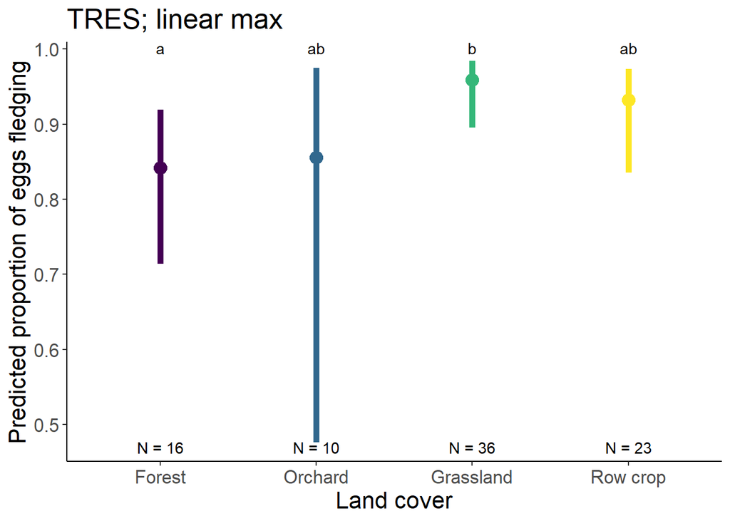

```r
samp <- s_inc_TRES_noint$data %>% group_by(habitat) %>% summarize(count = n())
# samp %>% gt() %>% gtsave("../figures/ss_TRES.html")


dat_text <- data.frame(
label = paste("N =",samp$count),
group = factor(samp$habitat)
)



dat <- predict_response(s_inc_TRES_noint,terms = c("habitat"))

(pl <- ggplot(data = dat, mapping = aes(x = x, color = x, y = predicted,ymin = conf.low,ymax = conf.high)) +
   # plot(line_size = 1.5,alpha = .2,show_data = TRUE,limit_range = TRUE,colors = viridis(4)) +
   geom_point(size = 4) +
    geom_linerange(linewidth = 2) +
   theme_classic() +
   #facet_wrap(~ group, ncol = 2) +
    xlab("Land cover") +
    ylab("Predicted proportion of eggs fledging") +
   # scale_fill_viridis(discrete = TRUE) +
   scale_color_manual(values = viridis(4)) +
    theme(text = element_text(size = 16)) +
    labs(title = "TRES; linear max") +
   # scale_x_continuous(trans = temp_trans,
   #                     breaks = c((20-mean_temp)/sd_temp,
   #                                (25-mean_temp)/sd_temp,
   #                                (30-mean_temp)/sd_temp,
   #                                (35-mean_temp)/sd_temp,
   #                                (40-mean_temp)/sd_temp#,
   #                                #(45-mean_temp)/sd_temp
   #                                ),
   #                     # breaks = c(20,30,40,50),
   #                     # labels = c("20","30","40","50"),
   #                     # limits = c((15-mean(g$meanmaxtempI,na.rm = TRUE))/sd(g$meanmaxtempI,na.rm = TRUE),
   #                     #            (55-mean(g$meanmaxtempI,na.rm = TRUE))/sd(g$meanmaxtempI,na.rm = TRUE))
   #                     # limits = c(18,5)
   #                     ) +
   # ylim(0,100) +
   geom_text(data = dat_text, mapping = aes(x = c(1,2,3,4), y = -Inf,label = label),hjust = .5,vjust = -.7,inherit.aes = FALSE) +
    theme(legend.position = "none") +
    annotate(geom = "text", x = c(1,2,3,4),y = Inf,hjust = .5,vjust = 1,label = c("a","ab","b","ab"))
 )
```

#### Nestling model

```r
s_nest_TRES <- glm(cbind(nest_fledged,brood_size - nest_fledged) ~ meanmaxt_nest_scaled * habitat + meanmint_nest_scaled * habitat + juliandate_hatch_scaled + year_fct + site,
               family = binomial(link = "logit"),
               data = dplyr::filter(s,
                                    Species == "TRES",
                                    !is.na(nest_fledged),
                                    !is.na(brood_size)) %>%
                 mutate(across(c(meanmaxt_nest,meanmint_nest,juliandate_hatch),
                               ~ scale(.x)[,1],
                               .names = "{.col}_scaled")
                      )
               )

s_nest_TRES_addmax <- glm(cbind(nest_fledged,brood_size - nest_fledged) ~ meanmaxt_nest_scaled + meanmint_nest_scaled * habitat + juliandate_hatch_scaled + year_fct + site,
               family = binomial(link = "logit"),
               data = dplyr::filter(s,
                                    Species == "TRES",
                                    !is.na(nest_fledged),
                                    !is.na(brood_size)) %>%
                 mutate(across(c(meanmaxt_nest,meanmint_nest,juliandate_hatch),
                               ~ scale(.x)[,1],
                               .names = "{.col}_scaled")
                      )
               )

s_nest_TRES_addmin <- glm(cbind(nest_fledged,brood_size - nest_fledged) ~ meanmaxt_nest_scaled * habitat + meanmint_nest_scaled + juliandate_hatch_scaled + year_fct + site,
               family = binomial(link = "logit"),
               data = dplyr::filter(s,
                                    Species == "TRES",
                                    !is.na(nest_fledged),
                                    !is.na(brood_size)) %>%
                 mutate(across(c(meanmaxt_nest,meanmint_nest,juliandate_hatch),
                               ~ scale(.x)[,1],
                               .names = "{.col}_scaled")
                      )
               )
s_nest_TRES_noint <- glm(cbind(nest_fledged,brood_size - nest_fledged) ~ meanmaxt_nest_scaled + meanmint_nest_scaled + habitat + juliandate_hatch_scaled + year_fct + site,
               family = binomial(link = "logit"),
               data = dplyr::filter(s,
                                    Species == "TRES",
                                    !is.na(nest_fledged),
                                    !is.na(brood_size)) %>%
                 mutate(across(c(meanmaxt_nest,meanmint_nest,juliandate_hatch),
                               ~ scale(.x)[,1],
                               .names = "{.col}_scaled")
                      )
               )

c1 <- anova(s_nest_TRES,s_nest_TRES_addmin,s_nest_TRES_noint) %>% tibble() %>% mutate(Model = c("no interaction","single interaction","both interacting"),.before = Df)

c2 <- anova(s_nest_TRES,s_nest_TRES_addmax,s_nest_TRES_noint) %>% tibble() %>% mutate(Model = c("no interaction","single interaction","both interacting"),.before = Df)

(tab <- bind_rows(c1,c2) %>%
  as_tibble() %>%
  mutate(across(where(is.numeric),~round(.x,digits = 4)),
         P = `Pr(>Chi)`) %>%
  dplyr::select(Model,Deviance,P) %>%
  mutate(max_or_min = c(rep("Max temp",times = 3),rep("Min temp",times = 3)),
         across(c(Deviance), ~ round(.x, digits = 2)),
         P = if_else(P < 0.001,"<0.001",as.character(P))) %>%
  group_by(max_or_min) %>% gt())
```

| Model | Deviance | P |
| --- | --- | --- |
| Max temp |  |  |
| no interaction | NA | NA |
| single interaction | -3.20 | 0.3614 |
| both interacting | -3.45 | 0.3275 |
| Min temp |  |  |
| no interaction | NA | NA |
| single interaction | -3.72 | 0.2931 |
| both interacting | -2.93 | 0.4026 |

```r
gtsave(tab,"../figures/int_tab_survival_nest_tres.html")
```

For TRES nestlings, neither max nor mean temp interacts with land cover.

```r
summary(s_nest_TRES_noint)
```

```
##
## Call:
## glm(formula = cbind(nest_fledged, brood_size - nest_fledged) ~
##     meanmaxt_nest_scaled + meanmint_nest_scaled + habitat + juliandate_hatch_scaled +
##         year_fct + site, family = binomial(link = "logit"), data = dplyr::filter(s,
##     Species == "TRES", !is.na(nest_fledged), !is.na(brood_size)) %>%
##     mutate(across(c(meanmaxt_nest, meanmint_nest, juliandate_hatch),
##         ~scale(.x)[, 1], .names = "{.col}_scaled")))
##
## Coefficients:
##                          Estimate Std. Error z value Pr(>|z|)
## (Intercept)                0.7323     0.4271   1.714   0.0864 .
## meanmaxt_nest_scaled       0.3339     0.2998   1.114   0.2653
## meanmint_nest_scaled       0.1744     0.3406   0.512   0.6087
## habitatOrchard            16.1419  1232.2009   0.013   0.9895
## habitatGrassland           1.3001     0.6252   2.080   0.0376 *
## habitatRow crop            1.2728     0.5602   2.272   0.0231 *
## juliandate_hatch_scaled   -0.6812     0.2662  -2.559   0.0105 *
## year_fct2022               0.8531     0.4551   1.875   0.0608 .
## year_fct2023               1.2292     0.5347   2.299   0.0215 *
## sitePG                    -0.2567     0.5163  -0.497   0.6190
## siteRR                    -0.9609     0.5049  -1.903   0.0570 .
## siteWI                   -17.4678  1232.2010  -0.014   0.9887
## ---
## Signif. codes:  0 '***' 0.001 '**' 0.01 '*' 0.05 '.' 0.1 ' ' 1
##
## (Dispersion parameter for binomial family taken to be 1)
##
##     Null deviance: 179.7  on 63  degrees of freedom
## Residual deviance: 134.5  on 52  degrees of freedom
##   (1 observation deleted due to missingness)
## AIC: 185.25
##
## Number of Fisher Scoring iterations: 15
```

```r
(t <- emmeans(s_nest_TRES_noint,"habitat") %>% pairs() %>% as_tibble() %>%
   mutate(across(estimate:z.ratio,~round(.x,digits = 2)),
          across(p.value,~round(.x,digits = 3))) %>% gt())
```

| contrast | estimate | SE | df | z.ratio | p.value |
| --- | --- | --- | --- | --- | --- |
| Forest - Orchard | -16.14 | 1232.20 | Inf | -0.01 | 1.000 |
| Forest - Grassland | -1.30 | 0.63 | Inf | -2.08 | 0.160 |
| Forest - Row crop | -1.27 | 0.56 | Inf | -2.27 | 0.105 |
| Orchard - Grassland | 14.84 | 1232.20 | Inf | 0.01 | 1.000 |
| Orchard - Row crop | 14.87 | 1232.20 | Inf | 0.01 | 1.000 |
| Grassland - Row crop | 0.03 | 0.54 | Inf | 0.05 | 1.000 |

```r
gtsave(t,"../figures/survival_nest_byhabitat_tres.html")
```

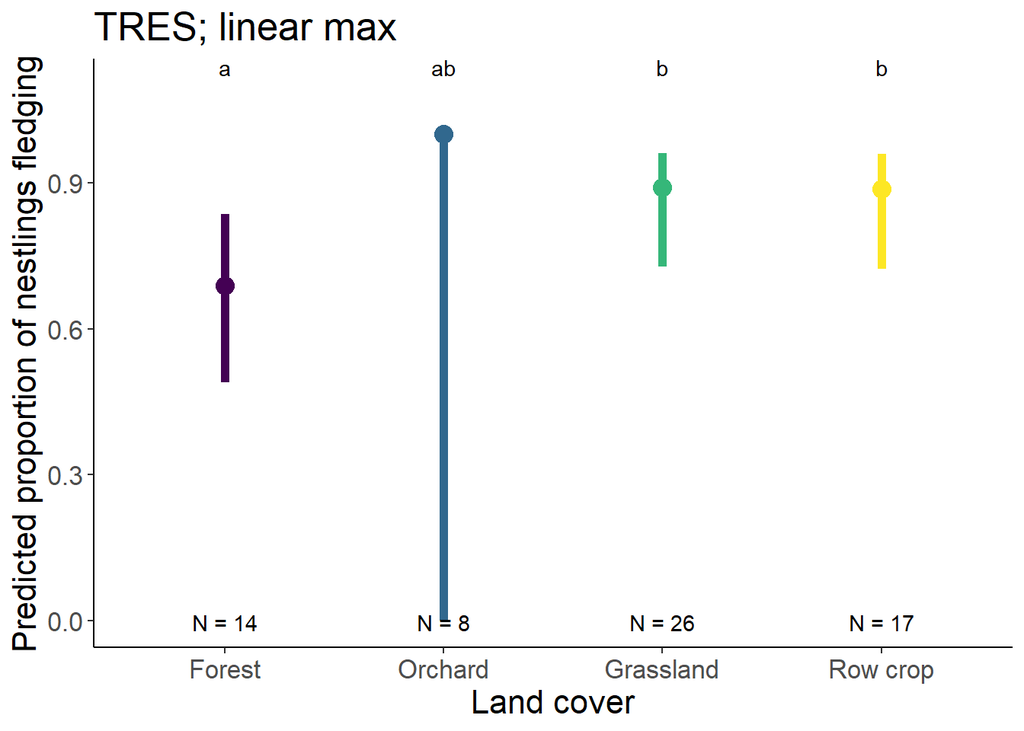

```r
samp <- s_nest_TRES_noint$data %>% group_by(habitat) %>% summarize(count = n())
# samp %>% gt() %>% gtsave("../figures/ss_TRES.html")


dat_text <- data.frame(
label = paste("N =",samp$count),
group = factor(samp$habitat)
)



dat <- predict_response(s_nest_TRES_noint,terms = c("habitat"))

(pl <- ggplot(data = dat, mapping = aes(x = x, color = x, y = predicted,ymin = conf.low,ymax = conf.high)) +
   # plot(line_size = 1.5,alpha = .2,show_data = TRUE,limit_range = TRUE,colors = viridis(4)) +
   geom_point(size = 4) +
    geom_linerange(linewidth = 2) +
   theme_classic() +
   #facet_wrap(~ group, ncol = 2) +
    xlab("Land cover") +
    ylab("Predicted proportion of nestlings fledging") +
   # scale_fill_viridis(discrete = TRUE) +
   scale_color_manual(values = viridis(4)) +
    theme(text = element_text(size = 16)) +
    labs(title = "TRES; linear max") +
   # scale_x_continuous(trans = temp_trans,
   #                     breaks = c((20-mean_temp)/sd_temp,
   #                                (25-mean_temp)/sd_temp,
   #                                (30-mean_temp)/sd_temp,
   #                                (35-mean_temp)/sd_temp,
   #                                (40-mean_temp)/sd_temp#,
   #                                #(45-mean_temp)/sd_temp
   #                                ),
   #                     # breaks = c(20,30,40,50),
   #                     # labels = c("20","30","40","50"),
   #                     # limits = c((15-mean(g$meanmaxtempI,na.rm = TRUE))/sd(g$meanmaxtempI,na.rm = TRUE),
   #                     #            (55-mean(g$meanmaxtempI,na.rm = TRUE))/sd(g$meanmaxtempI,na.rm = TRUE))
   #                     # limits = c(18,5)
   #                     ) +
   ylim(0,1.1) +
   geom_text(data = dat_text, mapping = aes(x = c(1,2,3,4), y = -Inf,label = label),hjust = .5,vjust = -1,inherit.aes = FALSE) +
    theme(legend.position = "none") +
    annotate(geom = "text", x = c(1,2,3,4),y = Inf,hjust = .5,vjust = 1,label = c("a","ab","b","b"))
 )
```

#### Nest period model

```r
s_nestpd_TRES <- glm(cbind(nest_fledged,clutch_size - nest_fledged) ~ meanmaxt_nestpd_scaled * habitat + meanmint_nestpd_scaled * habitat + juliandate_hatch_scaled + year_fct + site,
               family = binomial(link = "logit"),
               data = dplyr::filter(s,
                                    Species == "TRES",
                                    !is.na(nest_fledged),
                                    !is.na(clutch_size)) %>%
                 mutate(across(c(meanmaxt_nestpd,meanmint_nestpd,juliandate_hatch),
                               ~ scale(.x)[,1],
                               .names = "{.col}_scaled")
                      )
               )

s_nestpd_TRES_addmax <- glm(cbind(nest_fledged,clutch_size - nest_fledged) ~ meanmaxt_nestpd_scaled + meanmint_nestpd_scaled * habitat + juliandate_hatch_scaled + year_fct + site,
               family = binomial(link = "logit"),
               data = dplyr::filter(s,
                                    Species == "TRES",
                                    !is.na(nest_fledged),
                                    !is.na(clutch_size)) %>%
                 mutate(across(c(meanmaxt_nestpd,meanmint_nestpd,juliandate_hatch),
                               ~ scale(.x)[,1],
                               .names = "{.col}_scaled")
                      )
               )

s_nestpd_TRES_addmin <- glm(cbind(nest_fledged,clutch_size - nest_fledged) ~ meanmaxt_nestpd_scaled * habitat + meanmint_nestpd_scaled + juliandate_hatch_scaled + year_fct + site,
               family = binomial(link = "logit"),
               data = dplyr::filter(s,
                                    Species == "TRES",
                                    !is.na(nest_fledged),
                                    !is.na(clutch_size)) %>%
                 mutate(across(c(meanmaxt_nestpd,meanmint_nestpd,juliandate_hatch),
                               ~ scale(.x)[,1],
                               .names = "{.col}_scaled")
                      )
               )
s_nestpd_TRES_noint <- glm(cbind(nest_fledged,clutch_size - nest_fledged) ~ meanmaxt_nestpd_scaled + meanmint_nestpd_scaled + habitat + juliandate_hatch_scaled + year_fct + site,
               family = binomial(link = "logit"),
               data = dplyr::filter(s,
                                    Species == "TRES",
                                    !is.na(nest_fledged),
                                    !is.na(clutch_size)) %>%
                 mutate(across(c(meanmaxt_nestpd,meanmint_nestpd,juliandate_hatch),
                               ~ scale(.x)[,1],
                               .names = "{.col}_scaled")
                      )
               )

c1 <- anova(s_nestpd_TRES,s_nestpd_TRES_addmin,s_nestpd_TRES_noint) %>% tibble() %>% mutate(Model = c("no interaction","single interaction","both interacting"),.before = Df)

c2 <- anova(s_nestpd_TRES,s_nestpd_TRES_addmax,s_nestpd_TRES_noint) %>% tibble() %>% mutate(Model = c("no interaction","single interaction","both interacting"),.before = Df)

(tab <- bind_rows(c1,c2) %>%
  as_tibble() %>%
  mutate(across(where(is.numeric),~round(.x,digits = 4)),
         P = `Pr(>Chi)`) %>%
  dplyr::select(Model,Deviance,P) %>%
  mutate(max_or_min = c(rep("Max temp",times = 3),rep("Min temp",times = 3)),
         across(c(Deviance), ~ round(.x, digits = 2)),
         P = if_else(P < 0.001,"<0.001",as.character(P))) %>%
  group_by(max_or_min) %>% gt())
```

| Model | Deviance | P |
| --- | --- | --- |
| Max temp |  |  |
| no interaction | NA | NA |
| single interaction | -3.40 | 0.3339 |
| both interacting | -4.24 | 0.2362 |
| Min temp |  |  |
| no interaction | NA | NA |
| single interaction | -4.93 | 0.1773 |
| both interacting | -2.72 | 0.4369 |

```r
gtsave(tab,"../figures/int_tab_survival_nestpd_tres.html")
```

No interaction of land cover with max or min temp for TRES nest period.

```r
summary(s_nestpd_TRES_noint)
```

```
##
## Call:
## glm(formula = cbind(nest_fledged, clutch_size - nest_fledged) ~
##     meanmaxt_nestpd_scaled + meanmint_nestpd_scaled + habitat +
##         juliandate_hatch_scaled + year_fct + site, family = binomial(link = "logit"),
##     data = dplyr::filter(s, Species == "TRES", !is.na(nest_fledged),
##         !is.na(clutch_size)) %>% mutate(across(c(meanmaxt_nestpd,
##         meanmint_nestpd, juliandate_hatch), ~scale(.x)[, 1],
##         .names = "{.col}_scaled")))
##
## Coefficients:
##                         Estimate Std. Error z value Pr(>|z|)
## (Intercept)              0.20651    0.33367   0.619  0.53598
## meanmaxt_nestpd_scaled   0.04199    0.23004   0.183  0.85516
## meanmint_nestpd_scaled   0.23157    0.26758   0.865  0.38681
## habitatOrchard           0.44313    0.86985   0.509  0.61045
## habitatGrassland         1.44307    0.48850   2.954  0.00314 **
## habitatRow crop          1.08659    0.41326   2.629  0.00856 **
## juliandate_hatch_scaled -0.54721    0.25892  -2.113  0.03457 *
## year_fct2022             0.48770    0.34364   1.419  0.15584
## year_fct2023             0.83261    0.44767   1.860  0.06291 .
## sitePG                  -0.13315    0.39842  -0.334  0.73823
## siteRR                  -0.76134    0.40205  -1.894  0.05827 .
## siteWI                  -1.55570    1.01106  -1.539  0.12388
## ---
## Signif. codes:  0 '***' 0.001 '**' 0.01 '*' 0.05 '.' 0.1 ' ' 1
##
## (Dispersion parameter for binomial family taken to be 1)
##
##     Null deviance: 181.27  on 64  degrees of freedom
## Residual deviance: 138.59  on 53  degrees of freedom
## AIC: 228.39
##
## Number of Fisher Scoring iterations: 5
```

No main effects of max or mean temp. Effects of habitat?

```r
(t <- emmeans(s_nestpd_TRES_noint,"habitat") %>% pairs() %>% as_tibble() %>%
   mutate(across(estimate:z.ratio,~round(.x,digits = 2)),
          across(p.value,~round(.x,digits = 3))) %>% gt())
```

| contrast | estimate | SE | df | z.ratio | p.value |
| --- | --- | --- | --- | --- | --- |
| Forest - Orchard | -0.44 | 0.87 | Inf | -0.51 | 0.957 |
| Forest - Grassland | -1.44 | 0.49 | Inf | -2.95 | 0.017 |
| Forest - Row crop | -1.09 | 0.41 | Inf | -2.63 | 0.043 |
| Orchard - Grassland | -1.00 | 0.78 | Inf | -1.28 | 0.573 |
| Orchard - Row crop | -0.64 | 0.80 | Inf | -0.80 | 0.855 |
| Grassland - Row crop | 0.36 | 0.42 | Inf | 0.84 | 0.834 |

```r
gtsave(t,"../figures/survival_nestpd_byhabitat_tres.html")
```

Yes - survival is higher in grassland and row crop than in forest.

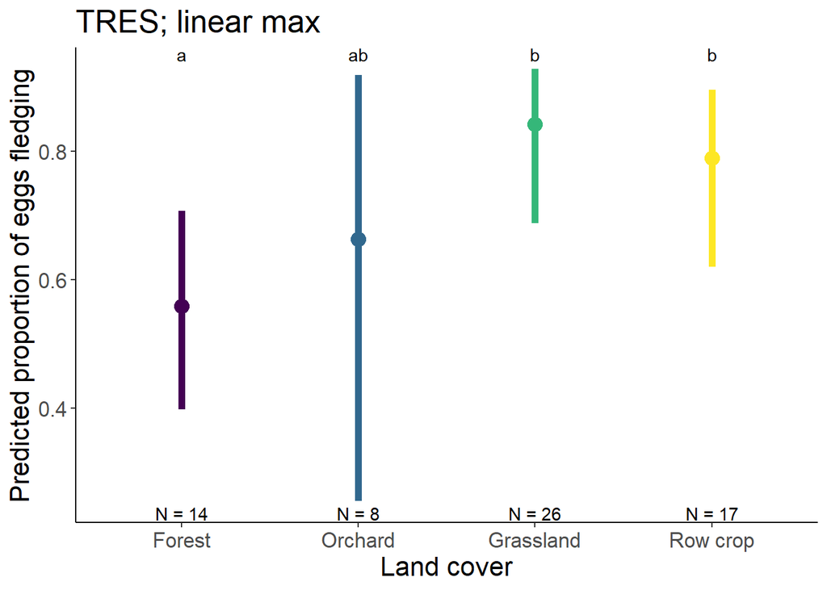

```r
samp <- s_nestpd_TRES_noint$data %>% group_by(habitat) %>% summarize(count = n())
# samp %>% gt() %>% gtsave("../figures/ss_TRES.html")


dat_text <- data.frame(
label = paste("N =",samp$count),
group = factor(samp$habitat)
)



dat <- predict_response(s_nestpd_TRES_noint,terms = c("habitat"))

(pl <- ggplot(data = dat, mapping = aes(x = x, color = x, y = predicted,ymin = conf.low,ymax = conf.high)) +
   # plot(line_size = 1.5,alpha = .2,show_data = TRUE,limit_range = TRUE,colors = viridis(4)) +
   geom_point(size = 4) +
    geom_linerange(linewidth = 2) +
   theme_classic() +
   #facet_wrap(~ group, ncol = 2) +
    xlab("Land cover") +
    ylab("Predicted proportion of eggs fledging") +
   # scale_fill_viridis(discrete = TRUE) +
   scale_color_manual(values = viridis(4)) +
    theme(text = element_text(size = 16)) +
    labs(title = "TRES; linear max") +
   # scale_x_continuous(trans = temp_trans,
   #                     breaks = c((20-mean_temp)/sd_temp,
   #                                (25-mean_temp)/sd_temp,
   #                                (30-mean_temp)/sd_temp,
   #                                (35-mean_temp)/sd_temp,
   #                                (40-mean_temp)/sd_temp#,
   #                                #(45-mean_temp)/sd_temp
   #                                ),
   #                     # breaks = c(20,30,40,50),
   #                     # labels = c("20","30","40","50"),
   #                     # limits = c((15-mean(g$meanmaxtempI,na.rm = TRUE))/sd(g$meanmaxtempI,na.rm = TRUE),
   #                     #            (55-mean(g$meanmaxtempI,na.rm = TRUE))/sd(g$meanmaxtempI,na.rm = TRUE))
   #                     # limits = c(18,5)
   #                     ) +
   # ylim(0,1.1) +
   geom_text(data = dat_text, mapping = aes(x = c(1,2,3,4), y = -Inf,label = label),hjust = .5,vjust = -.2,inherit.aes = FALSE) +
    theme(legend.position = "none") +
    annotate(geom = "text", x = c(1,2,3,4),y = Inf,hjust = .5,vjust = 1,label = c("a","ab","b","b"))
 )
```